# Taller 1 - Ciencia de Datos aplicada

Hecho por: María Paula Ospina 202123208, Andrés Camilo Beltrán 202511522

## Punto 1: Entendimiento inicial de datos

#### **Carga de datos e inspección inicial**

```python
import pandas as pd
import numpy as np
import matplotlib.pyplot as plt
import seaborn as sns

pd.set_option("display.max_columns", None)
pd.set_option("display.max_rows", 100)

secop_df = pd.read_parquet("secop_bienes.parquet")

secop_df.head()
```

|  | id_contrato | nombre_entidad | departamento | ciudad | orden | sector | rama | entidad_centralizada | tipo_de_contrato | modalidad_de_contratacion | codigo_de_categoria_principal | objeto_del_contrato | fecha_de_firma | fecha_de_inicio_del_contrato | fecha_de_fin_del_contrato | duraci_n_del_contrato | condiciones_de_entrega | proveedor_adjudicado | documento_proveedor | es_pyme | es_grupo | g_nero_representante_legal | nacionalidad_representante_legal | valor_del_contrato | valor_pagado | valor_facturado | valor_pendiente_de_pago | dias_adicionados | habilita_pago_adelantado | … |
| --- | --- | --- | --- | --- | --- | --- | --- | --- | --- | --- | --- | --- | --- | --- | --- | --- | --- | --- | --- | --- | --- | --- | --- | --- | --- | --- | --- | --- | --- | --- |
| 0 | CO1.PCCNTR.1000001 | PARQUES NACIONALES NATURALES DE COLOMBIA - DIR... | Distrito Capital de Bogotá | No Definido | Territorial | Ambiente y Desarrollo Sostenible | Ejecutivo | Centralizada | Suministros | Mínima cuantía | V1.50161509 | Contratar a monto agotable por el sistema de p... | 2019-06-19 | 2019-06-18 | 2019-12-31 | No definido | Como acordado previamente | INDUSTRIAS GUERRERO Y COMPAÑIA S.A.S. | 830130048 | Si | No | No Definido | CO | 17897916.0 | 17896237 | 17896237 | 1679 | 0 | No Definido | … |
| 1 | CO1.PCCNTR.1000507 | AGENCIA LOGISTICA DE LAS FUERZAS MILITARES | Distrito Capital de Bogotá | Bogotá | Nacional | defensa | Ejecutivo | Centralizada | Suministros | Selección Abreviada de Menor Cuantía | V1.50131612 | SUMINISTRO DE HUEVOS CON DESTINO A LOS COMEDOR... | 2019-06-23 | 2019-06-13 | 2019-11-29 | Dia(s) | Transporte incluido | Distribuidora Antioqueña AM | 21788564 | Si | No | Mujer | CO | 390000000.0 | 389999685 | 389999685 | 315 | 0 | No | … |
| 2 | CO1.PCCNTR.1000901 | FUERZA AEROESPACIAL COLOMBIANA | Distrito Capital de Bogotá | Bogotá | Nacional | defensa | Ejecutivo | Centralizada | Compraventa | Mínima cuantía | V1.53102701 | ADQUISICIÓN DE PRESILLAS BORDADAS AZULES EN CA... | 2019-06-18 | 2019-06-24 | 2019-09-30 | No definido | DAP - Entregado en un punto (lugar de destino ... | FANNY JANETH GUTIERREZ PRIETO | 20484821 | No | No | Mujer | CO | 11970000.0 | 11970000 | 11970000 | 0 | 0 | No Definido | … |
| 3 | CO1.PCCNTR.1000908 | AGENCIA LOGISTICA DE LAS FUERZAS MILITARES | Distrito Capital de Bogotá | Bogotá | Nacional | defensa | Ejecutivo | Centralizada | Compraventa | Licitación pública | V1.41115300 | ADQUISICIÓN DE UN SISTEMA DE SONAR 3D DE ALTA ... | 2019-07-25 | 2019-07-12 | 2019-11-30 | Dia(s) | Como acordado previamente | CASCO ANTIGUO | 76044753 | No | No | Otro | CO | 733992000.0 | 0 | 0 | 733992000 | 0 | No | … |
| 4 | CO1.PCCNTR.1000911 | PARQUES NACIONALES NATURALES DE COLOMBIA - DIR... | Bolívar | Cartagena | Territorial | Ambiente y Desarrollo Sostenible | Ejecutivo | Centralizada | Suministros | Mínima cuantía | V1.92121701 | Suministro de equipos para la instalación de t... | 2019-11-01 | 2019-06-17 | 2019-12-30 | No definido | No Definido | hr technology sas | 900815825 | Si | No | No Definido | CO | 6000000.0 | 0 | 0 | 6000000 | 0 | No Definido | … |

```python
# Showing dataset dimensions
secop_df.shape
```

```
(196391, 36)
```

```python
# Showing column types
secop_df.dtypes
```

```
id_contrato                                 object
nombre_entidad                              object
departamento                                object
ciudad                                      object
orden                                       object
sector                                      object
rama                                        object
entidad_centralizada                        object
tipo_de_contrato                            object
modalidad_de_contratacion                   object
codigo_de_categoria_principal               object
objeto_del_contrato                         object
fecha_de_firma                      datetime64[us]
fecha_de_inicio_del_contrato        datetime64[us]
fecha_de_fin_del_contrato           datetime64[us]
duraci_n_del_contrato                       object
condiciones_de_entrega                      object
proveedor_adjudicado                        object
documento_proveedor                         object
es_pyme                                     object
es_grupo                                    object
g_nero_representante_legal                  object
nacionalidad_representante_legal            object
valor_del_contrato                         float64
valor_pagado                                 int64
valor_facturado                              int64
valor_pendiente_de_pago                      int64
dias_adicionados                             int64
habilita_pago_adelantado                    object
el_contrato_puede_ser_prorrogado            object
origen_de_los_recursos                      object
destino_gasto                               object
estado_contrato                             object
liquidaci_n                                 object
obligaci_n_ambiental                        object
urlproceso                                  object
dtype: object
```

El conjunto de datos contiene 196.391 registros y 36 atributos asociados con contratos públicos de bienes. Se identifican principalmente variables categóricas, representadas como object; tres variables temporales (fecha_de_firma, fecha_de_inicio_del_contrato y fecha_de_fin_del_contrato), almacenadas correctamente como datetime64 y variables cuantitativas relacionadas principalmente con los valores económicos de los contratos y las adiciones de plazo. Esta combinación permite analizar tanto las características con las que se celebran los contratos como algunos resultados de su ejecución.

```python
# Showing a sample of n rows
secop_df.sample(5)
```

|  | id_contrato | nombre_entidad | departamento | ciudad | orden | sector | rama | entidad_centralizada | tipo_de_contrato | modalidad_de_contratacion | codigo_de_categoria_principal | objeto_del_contrato | fecha_de_firma | fecha_de_inicio_del_contrato | fecha_de_fin_del_contrato | duraci_n_del_contrato | condiciones_de_entrega | proveedor_adjudicado | documento_proveedor | es_pyme | es_grupo | g_nero_representante_legal | nacionalidad_representante_legal | valor_del_contrato | valor_pagado | valor_facturado | valor_pendiente_de_pago | dias_adicionados | habilita_pago_adelantado | … |
| --- | --- | --- | --- | --- | --- | --- | --- | --- | --- | --- | --- | --- | --- | --- | --- | --- | --- | --- | --- | --- | --- | --- | --- | --- | --- | --- | --- | --- | --- | --- |
| 126081 | CO1.PCCNTR.6408298 | CORPORACIÓN AUTÓNOMA REGIONAL DEL CANAL DEL DIQUE | Bolívar | Cartagena | Corporación Autónoma | Ambiente y Desarrollo Sostenible | Corporación Autónoma | Centralizada | Compraventa | Selección abreviada subasta inversa | V1.46181500 | ADQUISICIÓN DE ELEMENTOS DE PROTECCIÓN PERSONA... | 2024-06-07 | 2024-06-13 | 2024-09-12 | 3 Mes(es) | No Definido | LA GEMA S.A.S. | 900405496 | Si | No | Hombre | CO | 1.069622e+08 | 106962197 | 106962197 | 0 | 0 | No | … |
| 145540 | CO1.PCCNTR.7119104 | SUPERSOCIEDADES | No Definido | No Definido | Nacional | Industria | Ejecutivo | Centralizada | Compraventa | Selección abreviada subasta inversa | V1.43211500 | Adquisición de los derechos de\nfábrica con ga... | 2024-12-10 | 2024-12-11 | 2024-12-30 | 1 Mes(es) | NXTWY.DLVY.6 | Heimcore SAS | 900425697 | Si | No | Hombre | CO | 1.516699e+09 | 0 | 0 | 1516698957 | 0 | No | … |
| 173371 | CO1.PCCNTR.8283371 | MUNICIPIO DE PUERTO RICO - CAQUETA | Caquetá | Puerto Rico | Territorial | Servicio Público | Ejecutivo | Centralizada | Suministros | Contratación directa | V1.50192700 | SUMINISTRO DE KITS DE ALIMENTOS NO PERECEDEROS... | 2025-09-17 | 2025-09-22 | 2025-09-26 | 118 Dia(s) | NXTWY.DLVY.2 | YOLIBETH HERNANDEZ PERALTA | 1081157098 | No | No | Mujer | CO | 3.946783e+07 | 39467480 | 39467480 | 353 | 0 | No | … |
| 130576 | CO1.PCCNTR.6561825 | SENA REGIONAL CALDAS Grupo de Apoyo Administra... | Caldas | No Definido | Nacional | Trabajo | Ejecutivo | Centralizada | Compraventa | Mínima cuantía | V1.60105704 | ADQUIRIR LA PAPELERÍA; ÚTILES DE ESCRITORIO Y ... | 2024-07-25 | 2024-08-02 | 2024-08-23 | 23 Dia(s) | NXTWY.DLVY.2 | COMPUTAR SAS | 800226784 | Si | No | Mujer | CO | 1.558491e+07 | 15584909 | 15584909 | 0 | 8 | No | … |
| 176622 | CO1.PCCNTR.8399340 | ALCALDIA MUNICIPIO DE IBAGUE* | Tolima | Ibagué | Territorial | Servicio Público | Ejecutivo | Centralizada | Compraventa | Mínima cuantía | V1.45111815 | SC - 056 CONTRATAR LA DOTACIÓN DE ELEMENTOS TÉ... | 2025-10-06 | 2025-10-16 | 2025-12-02 | 2 Mes(es) | NXTWY.DLVY.2 | INNVECTOR SAS | 900235103 | Si | No | Mujer | CO | 8.782200e+07 | 0 | 87822000 | 87822000 | 0 | No | … |

#### **Cobertura temporal 2019-2025**

```python
secop_df["anio_firma"] = secop_df["fecha_de_firma"].dt.year

secop_df["anio_firma"].value_counts().sort_index()
```

```
anio_firma
2019    16425
2020    20135
2021    24043
2022    28070
2023    32971
2024    34634
2025    40113
Name: count, dtype: int64
```

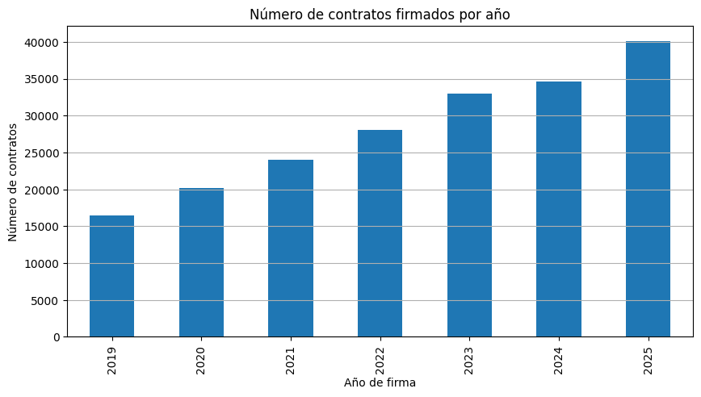

```python
secop_df["anio_firma"].value_counts().sort_index().plot(
    kind="bar",
    figsize=(10, 5)
)

plt.xlabel("Año de firma")
plt.ylabel("Número de contratos")
plt.title("Número de contratos firmados por año")
plt.grid(axis="y")
plt.show()
```

Se observa una tendencia creciente en el número de contratos de bienes registrados entre 2019 y 2025. El número de contratos pasa de 16.425 en 2019 a 40.113 en 2025, siendo este último el año con mayor número de registros. A diferencia de lo que podría ocurrir con un año de cobertura parcial, 2025 no presenta una reducción evidente en el número de contratos. Sin embargo, la diferencia en volumen entre los años indica que antes de considerarlos directamente comparables es necesario verificar la cobertura temporal y analizar si existen cambios en la composición de los contratos o en el registro de la información.

```python
#Comprobar que 2019 y 2025 realmente cubren el año completo
secop_df["fecha_de_firma"].min(), secop_df["fecha_de_firma"].max()
secop_df.groupby(secop_df["fecha_de_firma"].dt.year)["fecha_de_firma"].agg(["min", "max"])
```

| fecha_de_firma | min | max |
| --- | --- | --- |
| 2019 | 2019-01-01 | 2019-12-31 |
| 2020 | 2020-01-01 | 2020-12-31 |
| 2021 | 2021-01-01 | 2021-12-31 |
| 2022 | 2022-01-03 | 2022-12-31 |
| 2023 | 2023-01-01 | 2023-12-31 |
| 2024 | 2024-01-01 | 2024-12-31 |
| 2025 | 2025-01-01 | 2025-12-31 |

Las fechas mínimas y máximas muestran que todos los años tienen cobertura prácticamente completa: 2019, 2020, 2021, 2023, 2024 y 2025 van del 1 de enero al 31 de diciembre; 2022 comienza el 3 de enero, lo cual no es evidencia suficiente de un problema de cobertura. Por tanto, no hay una razón clara para excluir 2019 o 2025 por ser años parciales. El taller justamente nos pide justificar el periodo de análisis, y con esta evidencia podemos mantener inicialmente todo el periodo 2019–2025.

```python
#Comprobar que los contratos cubren completo el mes
contratos_mes = (secop_df.groupby([
        secop_df["fecha_de_firma"].dt.year,
        secop_df["fecha_de_firma"].dt.month ]).size().unstack()
)

contratos_mes
```

| fecha_de_firma | 1 | 2 | 3 | 4 | 5 | 6 | 7 | 8 | 9 | 10 | 11 | 12 |
| --- | --- | --- | --- | --- | --- | --- | --- | --- | --- | --- | --- | --- |
| 2019 | 548 | 1102 | 1314 | 1204 | 1567 | 1388 | 1633 | 1241 | 1368 | 1465 | 1635 | 1960 |
| 2020 | 380 | 744 | 1145 | 1687 | 1542 | 1694 | 1794 | 1606 | 1797 | 1898 | 2351 | 3497 |
| 2021 | 212 | 590 | 1245 | 1485 | 1717 | 2064 | 1957 | 2446 | 2536 | 2318 | 3092 | 4381 |
| 2022 | 411 | 909 | 2014 | 1655 | 2334 | 2487 | 2240 | 2598 | 2609 | 2527 | 3367 | 4919 |
| 2023 | 707 | 1505 | 2540 | 2224 | 2823 | 3073 | 2651 | 2936 | 2811 | 3111 | 3717 | 4873 |
| 2024 | 747 | 1707 | 2184 | 2749 | 3214 | 2729 | 2758 | 2816 | 2825 | 3320 | 3612 | 5973 |
| 2025 | 737 | 1868 | 2612 | 3108 | 3447 | 3201 | 3612 | 3082 | 3416 | 4126 | 4238 | 6666 |

La tabla mensual revela algo muy interesante: diciembre concentra sistemáticamente muchos más contratos, mientras enero y febrero suelen tener menos. Por ejemplo, diciembre pasa de 1.960 contratos en 2019 a 6.666 en 2025. También se confirma el crecimiento general que ya habíamos visto en los totales anuales.

```python
#está calculando, para cada año, el porcentaje de contratos que tuvieron al menos un día adicionado al plazo
pct_adiciones_anio = secop_df.groupby("anio_firma")["dias_adicionados"].apply(lambda x: (x > 0).mean() * 100)
```

La proporción de contratos con adiciones de plazo varía de manera importante entre años. Entre 2019 y 2024 se mantiene aproximadamente entre 4% y 9%, mientras que en 2025 aumenta hasta 17,29%. Este comportamiento sugiere que el año de firma puede estar asociado con diferencias en la frecuencia de adiciones de plazo. Sin embargo, antes de interpretar el incremento de 2025 como un deterioro en la ejecución contractual, es necesario verificar si existen cambios en la composición de los contratos, en las modalidades de contratación o en la forma de registro de la información.

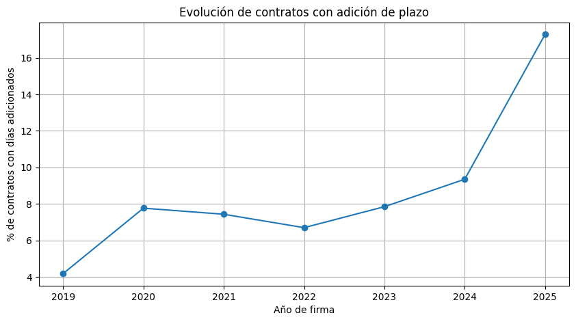

```python
pct_adiciones_anio.plot(
    figsize=(10, 5),
    marker="o"
)

plt.xlabel("Año de firma")
plt.ylabel("% de contratos con días adicionados")
plt.title("Evolución de contratos con adición de plazo")
plt.grid()
plt.show()
```

La proporción de contratos con adiciones de plazo presenta variaciones importantes durante el periodo analizado. Después de incrementarse entre 2019 y 2020, el indicador se mantiene relativamente estable entre 2020 y 2023, aumenta en 2024 y alcanza su valor más alto en 2025, cuando aproximadamente el 17,3% de los contratos registra al menos una adición de plazo. Este comportamiento sugiere que el año de firma podría estar asociado con diferencias en la ejecución contractual. Sin embargo, el incremento observado en 2025 debe analizarse conjuntamente con otras características de los contratos antes de atribuirlo a un deterioro general en la gestión.

#### **Diagnóstico básico de calidad**

**Buscar Valores Nulos**

```python
missing_report = pd.DataFrame({
    "n_missing": secop_df.isna().sum(),
    "pct_missing": secop_df.isna().mean() * 100
})
missing_report = missing_report.sort_values("pct_missing", ascending=False)
missing_report
```

|  | n_missing | pct_missing |
| --- | --- | --- |
| fecha_de_inicio_del_contrato | 2440 | 1.242419 |
| documento_proveedor | 4 | 0.002037 |
| dias_adicionados | 0 | 0.000000 |
| g_nero_representante_legal | 0 | 0.000000 |
| nacionalidad_representante_legal | 0 | 0.000000 |
| valor_del_contrato | 0 | 0.000000 |
| valor_pagado | 0 | 0.000000 |
| valor_facturado | 0 | 0.000000 |
| valor_pendiente_de_pago | 0 | 0.000000 |
| habilita_pago_adelantado | 0 | 0.000000 |
| es_pyme | 0 | 0.000000 |
| el_contrato_puede_ser_prorrogado | 0 | 0.000000 |
| origen_de_los_recursos | 0 | 0.000000 |
| destino_gasto | 0 | 0.000000 |
| estado_contrato | 0 | 0.000000 |
| liquidaci_n | 0 | 0.000000 |
| obligaci_n_ambiental | 0 | 0.000000 |
| urlproceso | 0 | 0.000000 |
| es_grupo | 0 | 0.000000 |
| id_contrato | 0 | 0.000000 |
| nombre_entidad | 0 | 0.000000 |
| tipo_de_contrato | 0 | 0.000000 |
| departamento | 0 | 0.000000 |
| ciudad | 0 | 0.000000 |
| orden | 0 | 0.000000 |
| sector | 0 | 0.000000 |
| rama | 0 | 0.000000 |
| entidad_centralizada | 0 | 0.000000 |
| modalidad_de_contratacion | 0 | 0.000000 |
| proveedor_adjudicado | 0 | 0.000000 |
| codigo_de_categoria_principal | 0 | 0.000000 |
| objeto_del_contrato | 0 | 0.000000 |
| fecha_de_firma | 0 | 0.000000 |
| fecha_de_fin_del_contrato | 0 | 0.000000 |
| duraci_n_del_contrato | 0 | 0.000000 |
| condiciones_de_entrega | 0 | 0.000000 |
| anio_firma | 0 | 0.000000 |

**Buscar "No definido"**

Lo hacemos porque isna() solamente detecta valores faltantes reales como NaN. Pero en SECOP aparecen cosas como "No Definido". Esos valores técnicamente existen pero pueden significar información no reportada.

```python
object_cols = secop_df.select_dtypes("object").columns
```

```python
for col in object_cols:
    x = secop_df[col].astype(str).str.strip().str.lower()
    n = x.eq("no definido").sum()
    if n > 0:
        print(col, n, round(n / len(secop_df) * 100, 2), "%")
```

```
departamento 7510 3.82 %
ciudad 41672 21.22 %
orden 9 0.0 %
sector 9 0.0 %
rama 9 0.0 %
objeto_del_contrato 1109 0.56 %
duraci_n_del_contrato 9490 4.83 %
condiciones_de_entrega 49971 25.44 %
proveedor_adjudicado 121 0.06 %
documento_proveedor 1563 0.8 %
g_nero_representante_legal 35822 18.24 %
nacionalidad_representante_legal 869 0.44 %
habilita_pago_adelantado 28507 14.52 %
destino_gasto 379 0.19 %
```

**Duplicados**

Queremos comprobar si existen filas completamente repetidas y si un mismo id_contrato aparece varias veces

```python
secop_df.duplicated().sum()
```

```
0
```

```python
secop_df["id_contrato"].duplicated().sum()
```

```
0
```

```python
secop_df["id_contrato"].nunique()
```

```
196391
```

Cada fila corresponde a un contrato diferente.

**Consistencia de fechas**

Queremos saber si las fechas cronologicamente tienen sentido

```python
#Fecha firma <= fecha inicio
m1 = secop_df["fecha_de_inicio_del_contrato"]
m2 = secop_df["fecha_de_firma"]

inicio_antes = secop_df.loc[m1 < m2]
print(f"Dimensiones:{inicio_antes.shape}")
print(f"Porcentaje:{len(inicio_antes) / len(secop_df) * 100}")
cols = ["id_contrato", "fecha_de_firma",
        "fecha_de_inicio_del_contrato"]
inicio_antes[cols].head(10)
```

```
Dimensiones:(13047, 37)
Porcentaje:6.643379788279503
```

|  | id_contrato | fecha_de_firma | fecha_de_inicio_del_contrato |
| --- | --- | --- | --- |
| 0 | CO1.PCCNTR.1000001 | 2019-06-19 | 2019-06-18 |
| 1 | CO1.PCCNTR.1000507 | 2019-06-23 | 2019-06-13 |
| 3 | CO1.PCCNTR.1000908 | 2019-07-25 | 2019-07-12 |
| 4 | CO1.PCCNTR.1000911 | 2019-11-01 | 2019-06-17 |
| 5 | CO1.PCCNTR.1000912 | 2019-06-19 | 2019-06-18 |
| 6 | CO1.PCCNTR.1000913 | 2019-07-11 | 2019-07-05 |
| 7 | CO1.PCCNTR.1000916 | 2019-07-11 | 2019-07-05 |
| 10 | CO1.PCCNTR.1000922 | 2019-06-26 | 2019-06-25 |
| 13 | CO1.PCCNTR.1001009 | 2019-07-05 | 2019-06-21 |
| 16 | CO1.PCCNTR.1001017 | 2019-06-20 | 2019-06-17 |

```python
#Fecha inicio <= Fecha Fin
m1 = secop_df["fecha_de_fin_del_contrato"]
m2 = secop_df["fecha_de_inicio_del_contrato"]

fin_antes = secop_df.loc[m1 < m2]
print(f"Dimensiones:{fin_antes.shape}")
print(f"Porcentaje:{len(fin_antes) / len(secop_df) * 100}")
cols = ["id_contrato", "fecha_de_firma",
        "fecha_de_inicio_del_contrato", "fecha_de_fin_del_contrato"]
fin_antes[cols].head(10)
```

```
Dimensiones:(125, 37)
Porcentaje:0.06364853786578814
```

|  | id_contrato | fecha_de_firma | fecha_de_inicio_del_contrato | fecha_de_fin_del_contrato |
| --- | --- | --- | --- | --- |
| 20778 | CO1.PCCNTR.1836130 | 2021-03-16 | 2021-03-16 | 2020-12-01 |
| 21873 | CO1.PCCNTR.1879066 | 2021-03-15 | 2021-03-15 | 2020-12-01 |
| 43226 | CO1.PCCNTR.2876744 | 2021-09-24 | 2021-10-29 | 2021-09-30 |
| 48983 | CO1.PCCNTR.3070546 | 2021-11-30 | 2022-12-01 | 2021-12-30 |
| 52996 | CO1.PCCNTR.3149016 | 2022-01-05 | 2022-01-05 | 2021-12-31 |
| 53371 | CO1.PCCNTR.3157920 | 2022-01-07 | 2022-03-01 | 2022-01-07 |
| 64215 | CO1.PCCNTR.3798225 | 2022-07-14 | 2023-07-27 | 2022-08-26 |
| 68787 | CO1.PCCNTR.3998005 | 2022-12-23 | 2022-12-23 | 2022-12-15 |
| 95083 | CO1.PCCNTR.5188383 | 2023-07-05 | 2024-07-05 | 2023-07-20 |
| 121713 | CO1.PCCNTR.6248107 | 2024-04-25 | 2024-04-25 | 2024-04-24 |

**Valores monetarios negativos**

Por su significado, un valor negativo sería sospechoso.

```python
money_cols = ["valor_del_contrato", "valor_pagado",
              "valor_facturado", "valor_pendiente_de_pago"]
print("Revisamos negativos")
for col in money_cols:
    print(col, (secop_df[col] < 0).sum())

print("Revisamos ceros")
#Revisamos ceros
for col in money_cols:
    print(col, (secop_df[col] == 0).sum())
```

```
Revisamos negativos
valor_del_contrato 0
valor_pagado 0
valor_facturado 0
valor_pendiente_de_pago 144
Revisamos ceros
valor_del_contrato 188
valor_pagado 107639
valor_facturado 91825
valor_pendiente_de_pago 57633
```

**valor_pagado > valor_del_contrato**

Conceptualmente esperaríamos que el valor pagado <= valor del contrato

```python
mask = secop_df["valor_pagado"] > secop_df["valor_del_contrato"]
mask.sum()
```

```
177
```

```python
cols = ["id_contrato", "valor_del_contrato",
        "valor_pagado", "estado_contrato"]
secop_df.loc[mask, cols].head(10)
```

|  | id_contrato | valor_del_contrato | valor_pagado | estado_contrato |
| --- | --- | --- | --- | --- |
| 639 | CO1.PCCNTR.1016208 | 2.024957e+07 | 20249568 | terminado |
| 913 | CO1.PCCNTR.1024512 | 8.658924e+07 | 86589237 | terminado |
| 6790 | CO1.PCCNTR.1184219 | 6.610556e+08 | 661055627 | terminado |
| 10608 | CO1.PCCNTR.1428032 | 3.104041e+08 | 310404140 | terminado |
| 10668 | CO1.PCCNTR.1431303 | 2.321063e+08 | 232106294 | terminado |
| 11214 | CO1.PCCNTR.1459837 | 6.188880e+07 | 61889100 | terminado |
| 11640 | CO1.PCCNTR.1475919 | 8.000000e+07 | 80000000 | terminado |
| 12544 | CO1.PCCNTR.1504068 | 8.928341e+07 | 89283413 | terminado |
| 13217 | CO1.PCCNTR.1529502 | 2.295033e+08 | 229503348 | Modificado |
| 13669 | CO1.PCCNTR.1546109 | 8.509509e+07 | 85095089 | terminado |

Pero no lo declaramos error todavía. Podría haber adiciones contractuales, actualizaciones del contrato, particularidades de cómo SECOP registra los valores

**valor_pendiente_de_pago < 0**

Si algo está “pendiente de pago”, intuitivamente esperaríamos valor pendiente ≥ 0

```python
mask = secop_df["valor_pendiente_de_pago"] < 0
mask.sum()
```

```
144
```

```python
cols = ["id_contrato", "valor_del_contrato",
        "valor_pagado", "valor_pendiente_de_pago"]
secop_df.loc[mask, cols].head(20)
```

|  | id_contrato | valor_del_contrato | valor_pagado | valor_pendiente_de_pago |
| --- | --- | --- | --- | --- |
| 639 | CO1.PCCNTR.1016208 | 2.024957e+07 | 20249568 | -2 |
| 913 | CO1.PCCNTR.1024512 | 8.658924e+07 | 86589237 | -2 |
| 6790 | CO1.PCCNTR.1184219 | 6.610556e+08 | 661055627 | -1 |
| 10608 | CO1.PCCNTR.1428032 | 3.104041e+08 | 310404140 | -40 |
| 10668 | CO1.PCCNTR.1431303 | 2.321063e+08 | 232106294 | -1 |
| 11214 | CO1.PCCNTR.1459837 | 6.188880e+07 | 61889100 | -300 |
| 11640 | CO1.PCCNTR.1475919 | 8.000000e+07 | 80000000 | -1 |
| 13217 | CO1.PCCNTR.1529502 | 2.295033e+08 | 229503348 | -18 |
| 13669 | CO1.PCCNTR.1546109 | 8.509509e+07 | 85095089 | -1 |
| 14115 | CO1.PCCNTR.1562737 | 4.071384e+07 | 44017700 | -3303860 |
| 15974 | CO1.PCCNTR.1633740 | 8.398356e+06 | 8440716 | -42360 |
| 16325 | CO1.PCCNTR.1647247 | 7.128848e+07 | 71288489 | -10 |
| 16373 | CO1.PCCNTR.1648048 | 3.815568e+08 | 384921236 | -3364476 |
| 17284 | CO1.PCCNTR.1686910 | 1.804001e+07 | 18040011 | -1 |
| 23739 | CO1.PCCNTR.1953633 | 5.213266e+08 | 534655044 | -13328482 |
| 24158 | CO1.PCCNTR.1968993 | 3.477752e+09 | 3478726492 | -974013 |
| 24417 | CO1.PCCNTR.1978244 | 6.853003e+07 | 68530028 | -1 |
| 25096 | CO1.PCCNTR.2001879 | 1.212491e+08 | 121249112 | -4 |
| 26002 | CO1.PCCNTR.2023879 | 7.096516e+08 | 709651608 | -2 |
| 27382 | CO1.PCCNTR.2052337 | 3.351661e+07 | 33798971 | -282364 |

**Consistencia entre contrato, pago y pendiente**

Queremos comprobar qué tan frecuentemente se cumple:

valor pendiente=valor contrato−valor pagado

```python
dif = secop_df["valor_del_contrato"] - secop_df["valor_pagado"]
(dif == secop_df["valor_pendiente_de_pago"]).mean() * 100
```

```
88.95621489783136
```

```python
#Para mirar donde no se cumple
mask = dif != secop_df["valor_pendiente_de_pago"]
cols = ["id_contrato", "valor_del_contrato",
        "valor_pagado", "valor_pendiente_de_pago"]
secop_df.loc[mask, cols].head(10)
```

|  | id_contrato | valor_del_contrato | valor_pagado | valor_pendiente_de_pago |
| --- | --- | --- | --- | --- |
| 30 | CO1.PCCNTR.1001203 | 8.251488e+07 | 0 | 82514884 |
| 42 | CO1.PCCNTR.1001230 | 1.998957e+07 | 19989568 | 0 |
| 55 | CO1.PCCNTR.1001625 | 1.382831e+09 | 53208638 | 1329622685 |
| 60 | CO1.PCCNTR.1002405 | 2.961219e+08 | 0 | 296121940 |
| 65 | CO1.PCCNTR.1002702 | 5.221876e+06 | 0 | 5221876 |
| 74 | CO1.PCCNTR.1002731 | 1.582227e+08 | 0 | 158222658 |
| 91 | CO1.PCCNTR.1002922 | 1.850821e+07 | 18507986 | 225 |
| 96 | CO1.PCCNTR.1002935 | 3.492290e+07 | 0 | 34922901 |
| 113 | CO1.PCCNTR.1003017 | 2.320372e+08 | 232037187 | 0 |
| 127 | CO1.PCCNTR.1003057 | 1.799000e+07 | 0 | 17989999 |

**Calidad de dias_adicionados**

Esta variable es importante porque seguramente será una de nuestras medidas de desviación.

```python
#Verificar si hay valores negativos
(secop_df["dias_adicionados"] < 0).sum()
```

```
0
```

```python
secop_df["dias_adicionados"].min()
```

```
0
```

```python
secop_df["dias_adicionados"].max()
```

```
14276
```

**Consistencia de variables categóricas**

Ahora queremos revisar las categorías.

```python
secop_df["modalidad_de_contratacion"].value_counts(dropna=False)
```

```
modalidad_de_contratacion
Mínima cuantía                                                 117753
Selección abreviada subasta inversa                             32907
Contratación régimen especial                                   19250
Selección Abreviada de Menor Cuantía                             8822
Contratación régimen especial (con ofertas)                      6154
Contratación Directa (con ofertas)                               5001
Contratación directa                                             3938
Licitación pública                                               2330
Seleccion Abreviada Menor Cuantia Sin Manifestacion Interes       236
Name: count, dtype: int64
```

```python
secop_df["sector"].value_counts(dropna=False)
```

```
sector
Servicio Público                                      37390
defensa                                               34585
No aplica/No pertenece                                24465
Salud y Protección Social                             22037
Ley de Justicia                                       20377
Trabajo                                               14759
Educación Nacional                                    10231
Ambiente y Desarrollo Sostenible                       8109
Transporte                                             4655
Cultura                                                2792
deportes                                               2610
Hacienda y Crédito Público                             2441
Industria                                              1807
Vivienda, Ciudad y Territorio                          1497
Planeación                                             1319
agricultura                                            1254
interior                                               1172
Minas y Energía                                        1025
Presidencia de la República                            1000
Inclusión Social y Reconciliación                       836
Tecnologías de la Información y las Comunicaciones      638
Ciencia Tecnología                                      481
Información Estadística                                 470
Relaciones Exteriores                                   332
Inteligencia Estratégica y Contrainteligencia           100
No Definido                                               9
Name: count, dtype: int64
```

```python
secop_df["estado_contrato"].value_counts(dropna=False)
```

```
estado_contrato
terminado       54230
En ejecución    51441
Cerrado         46824
Modificado      34462
Aprobado         9211
Suspendido        153
cedido             43
Cancelado          26
Borrador            1
Name: count, dtype: int64
```

```python
secop_df["liquidaci_n"].value_counts(dropna=False)
```

```
liquidaci_n
No    118418
Si     77973
Name: count, dtype: int64
```

```python
secop_df["destino_gasto"].value_counts(dropna=False)
```

```
destino_gasto
Funcionamiento    117097
Inversión          78383
No aplica            532
No Definido          379
Name: count, dtype: int64
```

**Diagnóstico de calidad.**

El conjunto de datos presenta una baja proporción de valores nulos explícitos: la principal ausencia se encuentra en fecha_de_inicio_del_contrato, con 2.440 registros (1,24%). Sin embargo, se identificaron valores como "No Definido" que representan información no reportada en varias variables categóricas, especialmente condiciones_de_entrega, ciudad, g_nero_representante_legal y habilita_pago_adelantado. Estos valores se conservaron como una categoría explícita para evitar imputaciones sin evidencia.

No se identificaron registros completamente duplicados ni identificadores de contrato repetidos. En cuanto a consistencia temporal, 13.047 contratos (6,64%) presentan una fecha de inicio anterior a la firma y 125 (0,064%) una fecha de finalización anterior al inicio. Debido a que no existe información suficiente para reconstruir las fechas correctas, estos registros se conservaron, pero serán excluidos de análisis que dependan directamente de la secuencia temporal.

En las variables monetarias no se encontraron valores negativos para el valor del contrato, pagado o facturado; sin embargo, se identificaron 144 valores negativos en valor_pendiente_de_pago y 177 contratos cuyo valor pagado supera el valor del contrato. Estas observaciones se marcaron como inconsistencias y no se utilizarán para construir indicadores de ejecución presupuestal cuando puedan producir resultados inválidos. Finalmente, dias_adicionados no contiene valores negativos, aunque presenta valores extremos que serán estudiados mediante análisis univariado antes de decidir cualquier tratamiento.

#### **Tratamiento de problemas de calidad**

```python
#copia para no modificar el dataset original
secop_clean = secop_df.copy()
```

**Nulos: no imputarlos ni eliminar todo**

Los valores nulos no fueron imputados debido a que no existe información suficiente para reconstruir los valores originales. Tampoco se eliminaron los registros completos, ya que contienen información válida en los demás atributos. Los contratos con fecha de inicio faltante se excluirán únicamente de los análisis que requieran explícitamente dicha fecha.

**"No Definido": unificar, pero conservar**

Los valores "No Definido" se conservaron como una categoría explícita de información no reportada. No se imputaron debido a que no existe una regla confiable para determinar el valor verdadero. Únicamente se estandarizó su escritura para evitar que distintas formas del mismo valor fueran interpretadas como categorías diferentes.

```python
object_cols = secop_clean.select_dtypes("object").columns
for col in object_cols:
    mask = secop_clean[col].astype(str).str.strip().str.lower()
    secop_clean.loc[mask.eq("no definido"), col] = "No Definido"
```

**Duplicados: no hay nada que tratar**

No se identificaron registros completamente duplicados ni identificadores de contrato repetidos. Por esta razón, no fue necesario eliminar observaciones por duplicidad.

**Fechas inconsistentes: crear una bandera**

Creamos una variable que nos diga si la cronología es válida. No vamos a cambiar las fechas

```python
secop_clean["fecha_valida"] = secop_clean["fecha_de_inicio_del_contrato"].notna()

secop_clean["fecha_valida"] &= (
    secop_clean["fecha_de_inicio_del_contrato"] >=
    secop_clean["fecha_de_firma"]
)

secop_clean["fecha_valida"] &= (
    secop_clean["fecha_de_fin_del_contrato"] >=
    secop_clean["fecha_de_inicio_del_contrato"]
)
```

Las inconsistencias cronológicas no fueron corregidas manualmente dado que no es posible determinar cuál de las fechas es incorrecta. En su lugar se creó una bandera de validez temporal. Los registros inconsistentes se conservarán para análisis que no dependan de las fechas y serán excluidos únicamente de cálculos temporales.

**Pendiente de pago negativo**

Se identificaron 144 contratos con valor_pendiente_de_pago negativo. Estos valores se consideraron inconsistentes con la interpretación de un monto pendiente y no fueron corregidos a cero, dado que esto implicaría imputar información sin evidencia. Se conservaron los contratos, pero estos casos serán excluidos cuando se analice la ejecución presupuestal.

```python
secop_clean["pendiente_valido"] = (secop_clean["valor_pendiente_de_pago"] >= 0)
```

**Pagos mayores al valor del contrato**

Los casos en los que el valor pagado supera el valor del contrato se marcaron como observaciones sospechosas, pero no se eliminaron automáticamente, dado que podrían estar asociados con modificaciones contractuales o particularidades del registro administrativo. Se excluirán únicamente al construir indicadores que requieran la relación entre valor contractual y valor pagado.

```python
secop_clean["pago_valido"] = (secop_clean["valor_pagado"] <=secop_clean["valor_del_contrato"])
```

**Contratos con valor cero**

Los contratos con valor contractual igual a cero se conservaron, debido a que no existe evidencia suficiente para clasificarlos como errores. Sin embargo, se excluirán de indicadores relativos que utilicen valor_del_contrato como denominador para evitar divisiones por cero.

**Valores extremos de dias_adicionados**

Los valores extremos de dias_adicionados se conservaron inicialmente debido a que no existe evidencia suficiente para concluir que sean errores de registro. Durante el análisis univariado se evaluará su magnitud mediante cuantiles e IQR y, de ser necesario, se aplicarán filtros únicamente para mejorar la visualización, sin eliminarlos automáticamente del conjunto de datos.

Se adoptó una estrategia conservadora con el objetivo de evitar la pérdida o modificación injustificada de información. Los valores faltantes y las categorías "No Definido" no fueron imputados debido a la ausencia de información que permita reconstruir sus valores reales. Las inconsistencias temporales y monetarias fueron identificadas mediante indicadores de validez y los registros afectados se conservaron para aquellos análisis en los que dichas variables no sean necesarias. Los valores monetarios negativos o incompatibles se excluirán únicamente de los indicadores que dependan de ellos. No fue necesario realizar tratamiento por duplicidad, dado que todos los identificadores de contrato son únicos. Finalmente, los valores extremos se conservaron inicialmente y serán evaluados durante el análisis univariado antes de tomar decisiones adicionales de filtrado.

#### **Top 5 de atributos y análisis univariado**

**Justificación de los 5 atributos seleccionados**

- **valor_del_contrato**: Se escogió porque muestra cuánto dinero está comprometido en cada contrato y ayuda a identificar cuáles podrían tener un mayor impacto económico si presentan problemas.
- **dias_adicionados**: Se escogió porque muestra si un contrato necesitó más tiempo del planeado, lo cual puede ser una señal de dificultades durante su ejecución.
- **valor_pendiente_de_pago**: Se escogió porque muestra cuánto dinero todavía está pendiente por pagar y ayuda a detectar contratos donde el presupuesto no se ha ejecutado completamente.
- **modalidad_de_contratacion**: Se escogió porque indica cómo se realizó la contratación y permite analizar después si algunas modalidades presentan más problemas que otras.
- **liquidaci_n**: Se escogió porque muestra si el contrato fue liquidado o no y ayuda a identificar contratos que terminaron pero todavía no han completado ese proceso.

**Atributo 1: Valor del Contrato**

Tipo: cuantitativa continua.

Aquí queremos entender cuál es el valor típico de un contrato, qué tan dispersos son los montos, qué tan asimétrica es la distribución y cuánto pesan los contratos extremos.

```python
secop_clean["valor_del_contrato"].describe(
    percentiles=[.25, .5, .75, .95, .99]
)
```

```
count    1.963910e+05
mean     6.582426e+10
std      2.901535e+13
min      0.000000e+00
25%      1.202121e+07
50%      3.360000e+07
75%      1.000000e+08
95%      8.000000e+08
99%      4.118482e+09
max      1.285845e+16
Name: valor_del_contrato, dtype: float64
```

```python
secop_clean["valor_del_contrato"].mean()
```

```
65824255027.864685
```

```python
mediana = secop_clean["valor_del_contrato"].median()
print(mediana)
```

```
33600000.0
```

```python
#Mediana con valores extremos. MAD
mad = (secop_clean["valor_del_contrato"] - mediana).abs().median()
print(mad)
```

```
26801275.0
```

```python
secop_clean["valor_del_contrato"].var()
```

```
8.418907078481698e+26
```

```python
secop_clean["valor_del_contrato"].std()
```

```
29015352967837.04
```

```python
#calculamos IQR para identificar valores extremos sin asumir que son errores.
q1 = secop_clean["valor_del_contrato"].quantile(.25)
q3 = secop_clean["valor_del_contrato"].quantile(.75)
iqr = q3 - q1
lower = q1 - 1.5 * iqr
upper = q3 + 1.5 * iqr
outliers = secop_clean.loc[
    (secop_clean["valor_del_contrato"] < lower) |
    (secop_clean["valor_del_contrato"] > upper)
]
len(outliers) / len(secop_clean) * 100
```

```
14.381514427850565
```

```python
print("Skewness:", secop_clean["valor_del_contrato"].skew())
print("Kurtosis:", secop_clean["valor_del_contrato"].kurtosis())
```

```
Skewness: 443.16015148594323
Kurtosis: 196390.94657048956
```

```python
valor_plot = secop_clean.loc[secop_clean["valor_del_contrato"] <= upper]
```

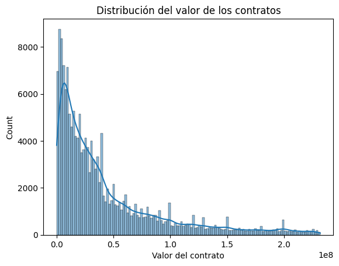

```python
sns.histplot(
    data=valor_plot,
    x="valor_del_contrato",
    kde=True
)
plt.title("Distribución del valor de los contratos")
plt.xlabel("Valor del contrato")
plt.show()
```

El valor_del_contrato presenta una distribución extremadamente asimétrica hacia la derecha. Aunque la media es de aproximadamente $65.824 millones, la mediana es de solo 33,6 millones, lo que muestra que el promedio está siendo fuertemente afectado por unos pocos contratos de valores excepcionalmente altos y, por tanto, no representa bien el contrato típico. De hecho, el 50% central de los contratos se encuentra entre aproximadamente 12 millones (Q1) y 100 millones (Q3), mientras que el percentil 95 es de 800 millones y el percentil 99 alcanza cerca de 4.118 millones; esto indica que la gran mayoría de los contratos se concentra en montos muy inferiores a los valores más extremos. Esta característica también se refleja en las medidas de dispersión: la desviación estándar y la varianza son muy elevadas debido a la influencia de los valores extremos, mientras que la desviación absoluta mediana (MAD), de aproximadamente 26,8 millones, ofrece una medida más representativa de la variabilidad alrededor de la mediana. La asimetría (skewness = 443,16) confirma una cola derecha extremadamente larga, y la curtosis (kurtosis = 196.390,95) evidencia una distribución con valores extremos muy pronunciados, por lo que medidas robustas como la mediana, los cuantiles, el IQR y el MAD son más apropiadas para describir esta variable que la media y la desviación estándar por sí solas. Aplicando el criterio de 1,5 veces el rango intercuartílico, aproximadamente el 14,38% de los contratos se clasifican como atípicos; sin embargo, estos registros no se consideran automáticamente errores, ya que en contratación pública es posible encontrar contratos legítimos de magnitudes muy diferentes. Por esta razón, el filtro de IQR se utilizó únicamente para facilitar la visualización y no para eliminar observaciones. El histograma filtrado confirma que la mayoría de los contratos se concentra en los montos más bajos y que la frecuencia disminuye a medida que aumenta el valor. En términos del objetivo del análisis, este comportamiento muestra una alta heterogeneidad económica entre los contratos y sugiere que existe un grupo relativamente reducido de contratos con una exposición financiera mucho mayor, cuya importancia para la supervisión deberá evaluarse posteriormente junto con otras características y desviaciones de la ejecución.

**Atributo 2: Dias_adicionados**

Tipo: cuantitativa discreta.

Aquí no se va a hacer lo mismo que con dinero porque hay una característica muy importante,probablemente hay una enorme concentración en 0.

La pregunta a responder es: ¿Qué tan común es adicionar plazo y cuando ocurre, qué tan grandes son las adiciones?

```python
#Tabla de frecuencias
secop_clean["dias_adicionados"].value_counts().head(15)
```

```
dias_adicionados
0     177720
31      1184
30      1155
15      1015
61       613
10       568
7        429
14       419
20       404
16       370
8        363
90       363
5        352
29       301
11       295
Name: count, dtype: int64
```

```python
#Frecuencia relativa
secop_clean["dias_adicionados"].value_counts(normalize=True).head(15) * 100
```

```
dias_adicionados
0     90.492945
31     0.602879
30     0.588112
15     0.516826
61     0.312132
10     0.289219
7      0.218442
14     0.213350
20     0.205712
16     0.188400
8      0.184835
90     0.184835
5      0.179234
29     0.153266
11     0.150211
Name: proportion, dtype: float64
```

```python
#Porcentaje sin y con adición
(secop_clean["dias_adicionados"] == 0).mean() * 100
```

```
90.49294519606296
```

```python
(secop_clean["dias_adicionados"] > 0).mean() * 100
```

```
9.507054803937045
```

```python
#Estadisticas y cuantiles
secop_clean["dias_adicionados"].describe(percentiles=[.25, .5, .75, .95, .99])
```

```
count    196391.000000
mean          5.107485
std          40.662426
min           0.000000
25%           0.000000
50%           0.000000
75%           0.000000
95%          30.000000
99%         122.000000
max       14276.000000
Name: dias_adicionados, dtype: float64
```

```python
#Forma de la distribución
print("Skewness:", secop_clean["dias_adicionados"].skew())
print("Kurtosis:", secop_clean["dias_adicionados"].kurtosis())
```

```
Skewness: 222.1917144972068
Kurtosis: 77269.88230930723
```

```python
#Analizar por separado los positivos
dias_pos = secop_clean.loc[
    secop_clean["dias_adicionados"] > 0,
    "dias_adicionados"
]
dias_pos.describe(
    percentiles=[.25, .5, .75, .95, .99]
)
```

```
count    18671.000000
mean        53.723100
std        121.575337
min          1.000000
25%         15.000000
50%         31.000000
75%         62.000000
95%        181.000000
99%        322.600000
max      14276.000000
Name: dias_adicionados, dtype: float64
```

```python
print("Skewness:", dias_pos.skew())
print("Kurtosis:", dias_pos.kurtosis())
```

```
Skewness: 86.1927405291891
Kurtosis: 10032.7716423923
```

```python
#IQR sobre contratos que sí tuvieron adición
q1 = dias_pos.quantile(.25)
q3 = dias_pos.quantile(.75)
iqr = q3 - q1
upper = q3 + 1.5 * iqr
(dias_pos > upper).mean() * 100
```

```
8.430185849713459
```

```python
dias_plot = dias_pos.loc[dias_pos <= upper]
```

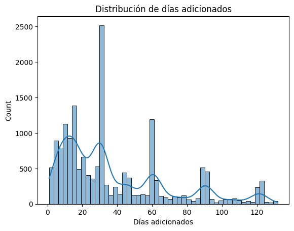

```python
sns.histplot(dias_plot, bins=50, kde=True)
plt.xlabel("Días adicionados")
plt.title("Distribución de días adicionados")
plt.show()
```

La variable dias_adicionados tiene una distribución muy concentrada en cero: el 90,49% de los contratos no registra días adicionales y solo el 9,51% presenta alguna adición de plazo. Esta concentración explica que la mediana, el primer cuartil y el tercer cuartil de la variable completa sean iguales a cero, así que aplicar el IQR directamente sobre todos los contratos resulta poco informativo. Aun así, hay una cola derecha muy pronunciada: el 95% de los contratos tiene como máximo 30 días adicionados y el 99% hasta 122, pero existe un máximo extremo de 14.276 días, lo cual se refleja en una asimetría muy alta (skewness = 222,19) y una curtosis elevada (77.269,88).

Por eso se analizaron por separado los 18.671 contratos que sí tuvieron adiciones. Dentro de este grupo la mediana es de 31 días, el 50% central está entre 15 y 62 días, el percentil 95 llega hasta 181 y el percentil 99 hasta cerca de 323. La media entre estos contratos es de 53,72 días, superior a la mediana, lo que confirma que los valores altos siguen desplazando el promedio hacia la derecha. Aplicando 1,5 veces el rango intercuartílico sobre los valores positivos, el límite superior es de aproximadamente 132,5 días y el 8,43% de los contratos con adición lo supera; estos casos no se eliminaron, dado que una adición extensa no necesariamente corresponde a un error, así que el filtro solo sirvió para visualizar mejor la distribución. El histograma muestra además concentraciones cerca de 15, 30, 60, 90 y 120 días, lo que sugiere que las adiciones suelen registrarse en plazos relativamente estandarizados.

Para el objetivo del taller, el hallazgo principal es que las adiciones de plazo son poco frecuentes en el conjunto total, pero cuando ocurren pueden alcanzar magnitudes muy distintas, por lo que esta variable resulta útil para distinguir contratos con desviaciones temporales más importantes.

**Atributo 3: valor_pendiente_de_pago**

Tipo: cuantitativa

Aquí aplicamos primero nuestra decisión de calidad: los 144 valores negativos no deben entrar en el análisis del monto pendiente.

```python
pendiente = secop_clean.loc[ secop_clean["valor_pendiente_de_pago"] >= 0,"valor_pendiente_de_pago"]
```

```python
pendiente.describe(percentiles=[.25, .5, .75, .95, .99])
```

```
count    1.962470e+05
mean     6.575298e+10
std      2.902600e+13
min      0.000000e+00
25%      0.000000e+00
50%      6.750000e+06
75%      4.250000e+07
95%      4.478891e+08
99%      2.612841e+09
max      1.285845e+16
Name: valor_pendiente_de_pago, dtype: float64
```

```python
#¿Cuántos tienen pendiente cero?
(pendiente == 0).mean() * 100
```

```
29.367582689162123
```

```python
(pendiente > 0).mean() * 100
```

```
70.63241731083787
```

```python
#Media, mediana y dispersión
print("Media:", pendiente.mean())
print("Mediana:", pendiente.median())
print("Varianza:", pendiente.var())
print("Desviación:", pendiente.std())
```

```
Media: 65752976781.91532
Mediana: 6750000.0
Varianza: 8.42508468258263e+26
Desviación: 29025996421454.043
```

```python
#MAD
mediana = pendiente.median()
mad = (pendiente - mediana).abs().median()
mad
```

```
6750000.0
```

```python
#IQR
q1 = pendiente.quantile(.25)
q3 = pendiente.quantile(.75)
iqr = q3 - q1
upper = q3 + 1.5 * iqr
(pendiente > upper).mean() * 100
```

```
14.14747741366747
```

```python
q3
```

```
42500000.0
```

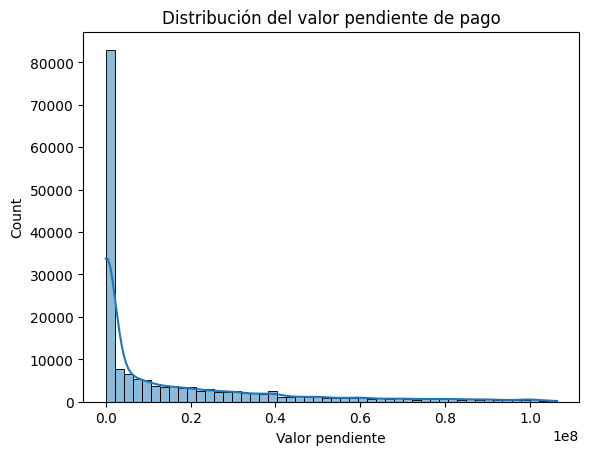

```python
pendiente_plot = pendiente.loc[pendiente <= upper]
sns.histplot(pendiente_plot, bins=50, kde=True)
plt.xlabel("Valor pendiente")
plt.title("Distribución del valor pendiente de pago")
plt.show()
```

El valor_pendiente_de_pago presenta una distribución fuertemente asimétrica hacia la derecha, dado que la mayoría de los contratos se concentra en valores bajos mientras que unos pocos alcanzan montos muy altos. Después de excluir los 144 valores negativos del diagnóstico de calidad, quedaron 196.247 registros, de los cuales el 29,37% tiene un valor pendiente igual a cero y el 70,63% presenta algún monto pendiente. La mediana es de $6,75 millones, mucho menor que la media de $65.753 millones, lo cual demuestra que son unos pocos valores extremos los que elevan el promedio y por lo tanto este no representa bien el comportamiento típico de la variable. El primer cuartil es $0 y el tercer cuartil $42,5 millones, así que el 50% central de los contratos está entre estos dos valores, mientras que el percentil 95 llega a cerca de $447,9 millones y el percentil 99 a cerca de $2.613 millones, lo que confirma que solo una pequeña proporción concentra montos mucho mayores. La desviación estándar también se ve muy afectada por estos extremos, por lo cual el MAD de $6,75 millones es una medida más robusta de la dispersión. Aplicando 1,5 veces el rango intercuartílico, el límite superior es de aproximadamente $106,25 millones y cerca del 14,15% de los registros lo supera; estos casos no se eliminaron, dado que un monto pendiente alto puede ser válido si corresponde a un contrato grande, así que el límite solo sirvió para facilitar la visualización, lo cual se confirma en el histograma. Para el objetivo del taller, esto muestra que los montos pendientes son muy heterogéneos y que hay un grupo de contratos con valores considerablemente mayores que podría ser relevante para la supervisión; sin embargo, más adelante conviene analizar el monto pendiente frente al valor total del contrato, dado que un mismo monto puede significar cosas muy distintas según el tamaño del contrato.

**Atributo 4: modalidad_de_contratacion**

Tipo: cualitativa nominal

```python
#Número de categorías
secop_clean["modalidad_de_contratacion"].nunique()
```

```
9
```

```python
#Moda
secop_clean["modalidad_de_contratacion"].mode()
```

```
0    Mínima cuantía
Name: modalidad_de_contratacion, dtype: object
```

```python
#Frecuencia absoluta
modalidad_frec = secop_clean[
    "modalidad_de_contratacion"
].value_counts()
modalidad_frec
```

```
modalidad_de_contratacion
Mínima cuantía                                                 117753
Selección abreviada subasta inversa                             32907
Contratación régimen especial                                   19250
Selección Abreviada de Menor Cuantía                             8822
Contratación régimen especial (con ofertas)                      6154
Contratación Directa (con ofertas)                               5001
Contratación directa                                             3938
Licitación pública                                               2330
Seleccion Abreviada Menor Cuantia Sin Manifestacion Interes       236
Name: count, dtype: int64
```

```python
#Frecuencia relativa
modalidad_pct = secop_clean[
    "modalidad_de_contratacion"
].value_counts(normalize=True) * 100
modalidad_pct
```

```
modalidad_de_contratacion
Mínima cuantía                                                 59.958450
Selección abreviada subasta inversa                            16.755859
Contratación régimen especial                                   9.801875
Selección Abreviada de Menor Cuantía                            4.492059
Contratación régimen especial (con ofertas)                     3.133545
Contratación Directa (con ofertas)                              2.546451
Contratación directa                                            2.005184
Licitación pública                                              1.186409
Seleccion Abreviada Menor Cuantia Sin Manifestacion Interes     0.120168
Name: proportion, dtype: float64
```

```python
#Concentración acumulada / Pareto
modalidad_cumsum = secop_clean[
    "modalidad_de_contratacion"
].value_counts(normalize=True).cumsum()
modalidad_cumsum
```

```
modalidad_de_contratacion
Mínima cuantía                                                 0.599585
Selección abreviada subasta inversa                            0.767143
Contratación régimen especial                                  0.865162
Selección Abreviada de Menor Cuantía                           0.910082
Contratación régimen especial (con ofertas)                    0.941418
Contratación Directa (con ofertas)                             0.966882
Contratación directa                                           0.986934
Licitación pública                                             0.998798
Seleccion Abreviada Menor Cuantia Sin Manifestacion Interes    1.000000
Name: proportion, dtype: float64
```

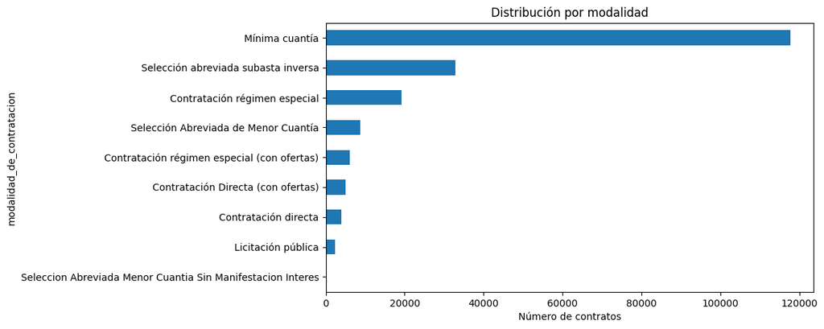

```python
modalidad_frec.sort_values().plot(
    kind="barh",
    figsize=(9, 5)
)
plt.xlabel("Número de contratos")
plt.title("Distribución por modalidad")
plt.show()
```

La variable modalidad_de_contratacion tiene 9 categorías y la distribución está muy concentrada en pocas de ellas. La categoría modal es mínima cuantía, con 117.753 contratos equivalentes al 59,96% del total, así que más de la mitad de los contratos se realizaron bajo esta modalidad. Le siguen selección abreviada por subasta inversa con 16,76% y contratación régimen especial con 9,80%, de modo que entre estas tres modalidades se concentra cerca del 86,52% de todos los contratos, mientras que las seis restantes representan apenas el 13,5%. El análisis acumulado tipo Pareto muestra además que con las cuatro modalidades más frecuentes ya se alcanza alrededor del 91% de las observaciones, lo cual confirma que la distribución no es uniforme sino que está fuertemente concentrada en unas pocas formas de contratación, sobre todo en mínima cuantía. Para el objetivo del taller esto es relevante porque la modalidad podría usarse más adelante como característica para segmentar los contratos y ver si las desviaciones de ejecución varían entre modalidades; sin embargo, en este análisis univariado solo se puede concluir que algunas modalidades tienen una representación mucho mayor que otras, por lo que cualquier comparación posterior deberá tener en cuenta esta diferencia en el número de contratos.

**Atributo 5: Liquidacion**

Tipo: cualitativa nominal

```python
#Valores únicos
secop_clean["liquidaci_n"].unique()
```

```
array(['Si', 'No'], dtype=object)
```

```python
#Frecuencia absoluta
liq_frec = secop_clean[
    "liquidaci_n"
].value_counts(dropna=False)
liq_frec
```

```
liquidaci_n
No    118418
Si     77973
Name: count, dtype: int64
```

```python
#Frecuencia relativa
liq_pct = secop_clean[
    "liquidaci_n"
].value_counts(
    normalize=True,
    dropna=False
) * 100
liq_pct
```

```
liquidaci_n
No    60.29706
Si    39.70294
Name: proportion, dtype: float64
```

```python
#Tabla conjunta
liq_tabla = pd.DataFrame({
    "frecuencia": liq_frec,
    "porcentaje": liq_pct
})
liq_tabla
```

| liquidaci_n | frecuencia | porcentaje |
| --- | --- | --- |
| No | 118418 | 60.29706 |
| Si | 77973 | 39.70294 |

```python
#Moda
secop_clean["liquidaci_n"].mode()
```

```
0    No
Name: liquidaci_n, dtype: object
```

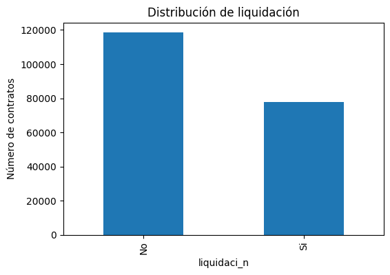

```python
liq_frec.plot(kind="bar", figsize=(6, 4))
plt.ylabel("Número de contratos")
plt.title("Distribución de liquidación")
plt.show()
```

La variable liquidacion tiene solo dos categorías, Sí y No, así que su distribución se interpreta fácilmente con frecuencias absolutas y relativas. La categoría más frecuente es No, con 118.418 contratos equivalentes al 60,30% del total, mientras que 77.973 contratos, cerca del 39,70%, aparecen registrados como liquidados, es decir que la mayoría de los contratos del conjunto de datos todavía no figura como liquidada. Aun así, esto no se debe interpretar por sí solo como una señal de incumplimiento, dado que un contrato puede no estar liquidado simplemente porque todavía está en ejecución o porque su proceso de cierre no ha terminado. Por eso liquidacion es una variable relevante para el objetivo del taller, pero su verdadero valor analítico va a aparecer más adelante al relacionarla con estado_contrato, sobre todo para identificar contratos que ya están terminados o cerrados y aun así no han sido liquidados. En términos univariados, el principal hallazgo es que hay una mayor proporción de contratos no liquidados que liquidados, con una diferencia cercana a 20,6 puntos porcentuales entre ambas categorías.

**Insights principales del punto 1**

En conjunto, el análisis inicial muestra que los contratos son bastante heterogéneos, tanto en su magnitud económica como en algunas características de su ejecución. Las variables monetarias, como valor_del_contrato y valor_pendiente_de_pago, tienen distribuciones fuertemente asimétricas y con valores extremos, por lo que la mediana, los cuantiles, el IQR y el MAD terminan siendo más representativos que la media por sí sola. En cuanto al plazo, la mayoría de los contratos no presenta días adicionados, pero entre los que sí tienen adiciones hay una variabilidad importante, con algunos casos considerablemente altos. Por otra parte, la contratación se concentra principalmente en pocas modalidades, sobre todo en mínima cuantía, y una mayor proporción de contratos aparece registrada como no liquidada. Esto sugiere que existen grupos de contratos con características muy distintas entre sí, y que variables como el valor, la modalidad, las adiciones de plazo, los montos pendientes y la liquidación podrían ser útiles más adelante para entender qué condiciones están asociadas con mayores desviaciones y así apoyar la focalización de la supervisión.

## Punto 2: Estrategia de análisis

La estrategia se va a enfocar en identificar si algunas características conocidas desde el inicio del contrato están asociadas con desviaciones posteriores en su ejecución. Se van a analizar tres señales principales: las adiciones de plazo, el porcentaje del valor contractual que queda pendiente de pago en los contratos finalizados, y los contratos terminados o cerrados que no aparecen liquidados. Estas señales se van a comparar principalmente con valor_del_contrato, modalidad_de_contratacion, sector y destino_gasto, buscando características que después puedan usarse como criterios de focalización. El análisis va a comenzar con proporciones, medianas y cuantiles, y va a continuar con tablas cruzadas y gráficos de barras para las variables categóricas, y con scatterplots, visualizaciones comparativas de medianas y medidas de correlación para las cuantitativas. Dado que en el punto anterior ya se había encontrado una fuerte asimetría y presencia de valores extremos, se le va a dar más peso a medianas, cuantiles y correlación de Spearman, y Pearson solo se va a usar si la relación entre dos variables cuantitativas resulta aproximadamente lineal.

Además del análisis descriptivo, se van a formular hipótesis explícitas para algunas de las relaciones más relevantes. Para las variables cuantitativas se plantea, de manera general, H0: no existe asociación entre la característica del contrato y la desviación analizada, frente a H1: sí existe asociación. Estas hipótesis se van a contrastar estadísticamente, y se van a reportar tanto los resultados significativos como los que no lo sean. Las relaciones entre varias variables cuantitativas se van a resumir con una matriz y un mapa de calor de correlaciones, mientras que las diferencias entre categorías se van a mostrar con tablas cruzadas, porcentajes y visualizaciones comparativas. Al final, los resultados se van a interpretar como asociaciones y no como relaciones causales, buscando los patrones que permitan proponer criterios concretos para priorizar la supervisión.

## Punto 3: Desarrollo de la estrategia

```python
analisis_df = secop_clean.copy()
```

**Desviación 1: adición de plazo**

Para facilitar el análisis de las desviaciones en la ejecución se creó una variable binaria que indica si cada contrato presentó o no una adición de plazo tomando como referencia si dias_adicionados es mayor que cero.

```python
analisis_df["adicion_plazo"] = (analisis_df["dias_adicionados"] > 0)
```

**Desviación 2: presupuesto pendiente**

Para poder comparar contratos de tamaños distintos, se calculó qué porcentaje del valor del contrato queda pendiente de pago. Esta medida resulta más útil que mirar solo el monto pendiente, dado que un mismo valor puede representar una proporción muy distinta según el tamaño del contrato.

```python
mask_pago = ((analisis_df["valor_del_contrato"] > 0) &(analisis_df["valor_pendiente_de_pago"] >= 0))
analisis_df.loc[mask_pago, "pct_pendiente"] = (analisis_df.loc[mask_pago, "valor_pendiente_de_pago"] /analisis_df.loc[mask_pago, "valor_del_contrato"] * 100)
```

Sin embargo, tener un porcentaje pendiente alto no necesariamente representa una desviación si el contrato todavía está en ejecución. Por eso, para estudiar esta señal, primero se identificaron los contratos que aparecen como terminados o cerrados.

```python
#Estandarizar el estado
analisis_df["estado_norm"] = (analisis_df["estado_contrato"].str.strip().str.lower())
#identificar contratos finalizados
analisis_df["finalizado"] = (analisis_df["estado_norm"].isin(["cerrado", "terminado"]))
```

Para el análisis del presupuesto pendiente se conservaron solo los contratos finalizados que tienen un porcentaje pendiente válido. Así se evita interpretar como una desviación un saldo que podría ser completamente normal en un contrato que todavía está en ejecución.

```python
finalizados_df = analisis_df.loc[analisis_df["finalizado"] &analisis_df["pct_pendiente"].notna()].copy()
```

```python
finalizados_df["pct_pendiente"].describe(percentiles=[.25, .5, .75, .95, .99])
```

```
count    100799.000000
mean         44.233607
std          48.731388
min           0.000000
25%           0.000000
50%           0.674555
75%         100.000000
95%         100.000000
99%         100.000000
max         419.733585
Name: pct_pendiente, dtype: float64
```

```python
(finalizados_df["pct_pendiente"] > 100).sum()
```

```
6
```

Se encontraron 6 contratos finalizados cuyo porcentaje pendiente supera el 100%. Estos valores se consideran inconsistentes para el análisis de ejecución presupuestal, dado que el saldo pendiente no debería superar el valor total del contrato. Por esta razón, estos contratos se van a conservar en el conjunto general, pero se van a excluir únicamente de los análisis que usen el porcentaje pendiente.

```python
finalizados_pago = finalizados_df.loc[finalizados_df["pct_pendiente"] <= 100].copy()
```

```python
(finalizados_pago["pct_pendiente"] == 0).mean() * 100
```

```
39.35392338753683
```

```python
(finalizados_pago["pct_pendiente"] == 100).mean() * 100
```

```
39.07116565634518
```

```python
((finalizados_pago["pct_pendiente"] > 0) &
 (finalizados_pago["pct_pendiente"] < 100)).mean() * 100
```

```
21.574910956117986
```

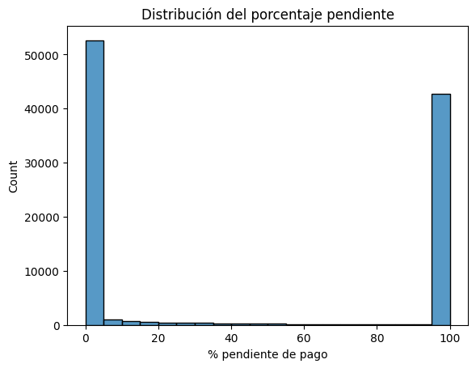

```python
sns.histplot(
    finalizados_pago["pct_pendiente"],
    bins=20
)
plt.xlabel("% pendiente de pago")
plt.title("Distribución del porcentaje pendiente")
plt.show()
```

Entre los contratos finalizados con un porcentaje pendiente válido, el 39,35% no presenta saldo pendiente de pago, mientras que el 39,07% registra el 100% del valor del contrato como pendiente, así que el 21,57% restante queda en una situación intermedia, con porcentajes entre 0% y 100%. El histograma confirma que la distribución está muy concentrada en los dos extremos, por lo que la media del porcentaje pendiente no representa bien el comportamiento típico de los contratos. Esto muestra que hay dos grupos claramente diferenciados: contratos finalizados sin saldo pendiente y contratos que, aunque aparecen como finalizados, todavía tienen registrado todo su valor como pendiente. Sin embargo, un porcentaje pendiente del 100% no se va a interpretar automáticamente como un incumplimiento, dado que podría estar relacionado con la forma o el momento en que se actualiza la información administrativa. Para los análisis posteriores esta diferencia se va a usar como una señal de posible desviación presupuestal, que deberá analizarse junto con otras características del contrato.

**Desviación 3: contratos finalizados sin liquidar**

La tercera señal de desviación corresponde a los contratos que ya aparecen como cerrados o terminados, pero que todavía están registrados como no liquidados. Para este análisis solo se consideran los contratos finalizados, ya que un contrato que aún se encuentra en ejecución no necesariamente debería estar liquidado.

```python
finalizados = analisis_df.loc[analisis_df["finalizado"]].copy()
#creamos la variable que identifica si está sin liquidar
finalizados["sin_liquidar"] = (finalizados["liquidaci_n"].str.strip().str.lower().eq("no"))
#revisamos cuántos hay
finalizados["sin_liquidar"].value_counts()
```

```
sin_liquidar
True     55896
False    45158
Name: count, dtype: int64
```

```python
#Y el porcentaje
finalizados["sin_liquidar"].value_counts( normalize=True) * 100
```

```
sin_liquidar
True     55.313001
False    44.686999
Name: proportion, dtype: float64
```

De los 101.054 contratos identificados como terminados o cerrados, 55.896 aparecen registrados como no liquidados, equivalente al 55,31%, mientras que el 44,69% restante sí aparece liquidado, lo cual significa que más de la mitad de los contratos que ya finalizaron su ejecución todavía no completan el proceso de liquidación. Esto se toma como una señal de posible desviación en el cierre del contrato, dado que permite identificar casos que, a pesar de haber terminado, siguen sin cerrarse del todo en la información disponible. Sin embargo, esta condición no se interpreta por sí sola como una irregularidad, sino como una señal que más adelante puede ser útil para priorizar contratos y ver si se concentra en ciertas modalidades, sectores o destinos del gasto.

**Análisis bivariado de las desviaciones**

*modalidad de contratación vs. presencia de adición de plazo*

Primero se analiza si la frecuencia de contratos con adiciones de plazo cambia según la modalidad de contratación. Para esto se utiliza una tabla cruzada con frecuencias relativas, ya que ambas variables son categóricas. Los porcentajes se calculan dentro de cada modalidad para poder comparar los grupos independientemente de la cantidad de contratos que tenga cada uno.

```python
tabla_modalidad = pd.crosstab(
    analisis_df["modalidad_de_contratacion"],
    analisis_df["adicion_plazo"],
    normalize="index"
) * 100

tabla_modalidad
```

| adicion_plazo modalidad_de_contratacion | False | True |
| --- | --- | --- |
| Contratación Directa (con ofertas) | 91.041792 | 8.958208 |
| Contratación directa | 92.458101 | 7.541899 |
| Contratación régimen especial | 93.771429 | 6.228571 |
| Contratación régimen especial (con ofertas) | 81.637959 | 18.362041 |
| Licitación pública | 74.163090 | 25.836910 |
| Mínima cuantía | 92.818017 | 7.181983 |
| Seleccion Abreviada Menor Cuantia Sin Manifestacion Interes | 80.084746 | 19.915254 |
| Selección Abreviada de Menor Cuantía | 85.264112 | 14.735888 |
| Selección abreviada subasta inversa | 84.225241 | 15.774759 |

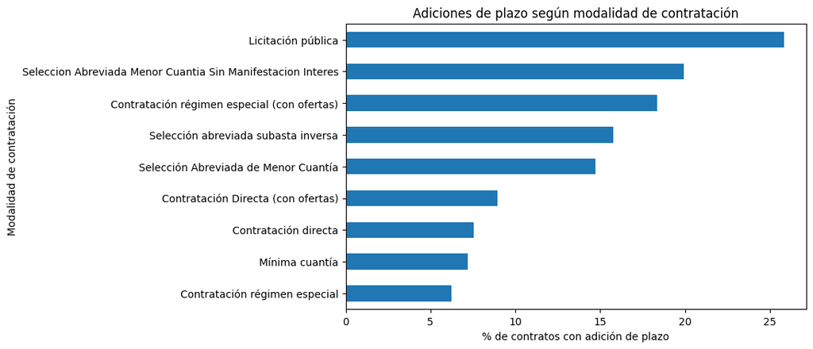

```python
porcentaje_adicion = tabla_modalidad[True].sort_values()

porcentaje_adicion.plot(
    kind="barh",
    figsize=(8, 5)
)

plt.xlabel("% de contratos con adición de plazo")
plt.ylabel("Modalidad de contratación")
plt.title("Adiciones de plazo según modalidad de contratación")
plt.show()
```

```python
analisis_df["modalidad_de_contratacion"].value_counts()
```

```
modalidad_de_contratacion
Mínima cuantía                                                 117753
Selección abreviada subasta inversa                             32907
Contratación régimen especial                                   19250
Selección Abreviada de Menor Cuantía                             8822
Contratación régimen especial (con ofertas)                      6154
Contratación Directa (con ofertas)                               5001
Contratación directa                                             3938
Licitación pública                                               2330
Seleccion Abreviada Menor Cuantia Sin Manifestacion Interes       236
Name: count, dtype: int64
```

La proporción de contratos con adiciones de plazo cambia según la modalidad de contratación. La mayor proporción se ve en Licitación pública, donde el 25,84% de los 2.330 contratos presentó alguna adición de plazo. Le sigue Selección Abreviada Menor Cuantía Sin Manifestación de Interés con 19,92%, aunque esta modalidad solo tiene 236 contratos, y Contratación régimen especial (con ofertas) con 18,36% sobre 6.154 contratos. También hay proporciones relativamente altas en Selección abreviada subasta inversa, con 15,77% sobre 32.907 contratos, y Selección Abreviada de Menor Cuantía, con 14,74% sobre 8.822 contratos.

En cambio, las proporciones más bajas de adiciones se dan en Contratación régimen especial con 6,23%, Mínima cuantía con 7,18%, Contratación directa con 7,54% y Contratación Directa (con ofertas) con 8,96%. Aquí también hay que tener en cuenta el tamaño de cada modalidad: Mínima cuantía, por ejemplo, concentra 117.753 contratos, así que ese porcentaje está respaldado por una cantidad muy grande de casos, mientras que el 19,92% de Selección Abreviada Menor Cuantía Sin Manifestación de Interés hay que tomarlo con más cuidado porque solo tiene 236 contratos.

En términos descriptivos, esto muestra que la frecuencia de las adiciones de plazo no es igual entre todas las modalidades. Licitación pública destaca por tener la mayor proporción, mientras que modalidades como Contratación régimen especial, Mínima cuantía y Contratación directa tienen valores bastante menores. Esto indica que la modalidad de contratación podría ser una característica relevante para la focalización de la supervisión. Aun así, estas diferencias siguen siendo descriptivas, y se necesita un contraste de hipótesis para determinar si la asociación entre la modalidad de contratación y la presencia de adiciones es estadísticamente significativa.

*valor_del_contrato vs. dias_adicionados*

A continuación se analiza si el valor inicial del contrato tiene relación con la magnitud de las adiciones de plazo. Ambas variables son cuantitativas, así que primero se visualiza la relación con un scatterplot y después se calcula la correlación de Spearman, que se usa por la fuerte asimetría y presencia de valores extremos que ya se había visto antes.

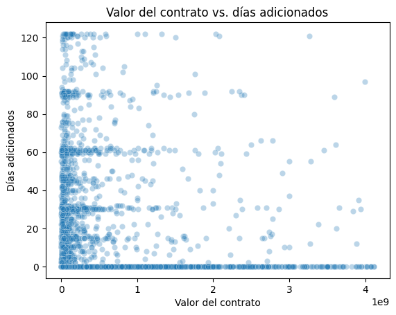

```python
#Primero hacemos la gráfica
muestra = analisis_df.sample(frac=0.1, random_state=42)

x99 = analisis_df["valor_del_contrato"].quantile(.99)
y99 = analisis_df["dias_adicionados"].quantile(.99)

muestra_plot = muestra.loc[
    (muestra["valor_del_contrato"] <= x99) &
    (muestra["dias_adicionados"] <= y99)
]
sns.scatterplot(
    data=muestra_plot,
    x="valor_del_contrato",
    y="dias_adicionados",
    alpha=.3
)

plt.xlabel("Valor del contrato")
plt.ylabel("Días adicionados")
plt.title("Valor del contrato vs. días adicionados")
plt.show()
```

*Hipótesis*

- **H0:** no existe una asociación entre el valor del contrato y los días adicionados.
- **H1:** existe una asociación entre el valor del contrato y los días adicionados.

```python
#Calculamos spearman
analisis_df[["valor_del_contrato", "dias_adicionados"]].corr(method="spearman")
```

|  | valor_del_contrato | dias_adicionados |
| --- | --- | --- |
| valor_del_contrato | 1.000000 | 0.186366 |
| dias_adicionados | 0.186366 | 1.000000 |

Para contrastar las hipótesis se calcula el valor p asociado a la correlación de Spearman, usando un nivel de significancia de 0,05. Si el valor p resulta menor a 0,05 se rechaza H0; si no, no se rechaza.

```python
from scipy.stats import spearmanr

datos_corr = analisis_df[["valor_del_contrato", "dias_adicionados"]].dropna()

rho, p_valor = spearmanr(datos_corr["valor_del_contrato"],datos_corr["dias_adicionados"])
print("Spearman:", rho)
print("p-valor:", p_valor)
```

```
Spearman: 0.18636633607797592
p-valor: 0.0
```

El scatterplot no muestra una relación lineal clara entre el valor del contrato y los días adicionados. Se ve una gran concentración de contratos con cero días adicionados, y bastante dispersión entre los que sí presentan adiciones.

La correlación de Spearman fue de 0,186, lo que indica una asociación positiva pero débil entre las dos variables: a medida que aumenta el valor del contrato, los días adicionados tienden a aumentar un poco, aunque la relación no es fuerte.

Al contrastar las hipótesis se obtuvo un valor p menor a 0,001, así que al ser inferior al nivel de significancia de 0,05 se rechaza H0 y se concluye que sí hay evidencia estadística de una asociación entre el valor del contrato y los días adicionados. Aun así, la magnitud de la correlación es baja, por lo que el valor del contrato por sí solo no permite explicar de manera importante la cantidad de días adicionados, y esta asociación tampoco se debe interpretar como una relación causal.

*pct_pendiente vs modalidad_de_contratacion*

A continuación se analiza si el porcentaje pendiente de pago de los contratos finalizados cambia según la modalidad de contratación. Para esta comparación se usa la mediana, dado que la distribución que se vio antes tiene una fuerte concentración en 0% y 100%.También se utiliza una visualización de las medianas por modalidad, ya que la fuerte concentración del porcentaje pendiente en valores cercanos a 0% y 100% hace que el boxplot sea poco informativo para esta comparación.

```python
#calculemos cuántos contratos hay y la mediana por modalidad
resumen_pago = finalizados_pago.groupby(
    "modalidad_de_contratacion"
)["pct_pendiente"].agg(["count", "median"])

resumen_pago.sort_values("median", ascending=False)
```

| modalidad_de_contratacion | count | median |
| --- | --- | --- |
| Contratación directa | 1773 | 100.000000 |
| Contratación régimen especial | 8938 | 100.000000 |
| Contratación régimen especial (con ofertas) | 2905 | 100.000000 |
| Selección Abreviada de Menor Cuantía | 4710 | 49.749323 |
| Seleccion Abreviada Menor Cuantia Sin Manifestacion Interes | 139 | 14.808571 |
| Licitación pública | 1117 | 12.030490 |
| Contratación Directa (con ofertas) | 2783 | 1.662779 |
| Selección abreviada subasta inversa | 17198 | 0.162474 |
| Mínima cuantía | 61230 | 0.007332 |

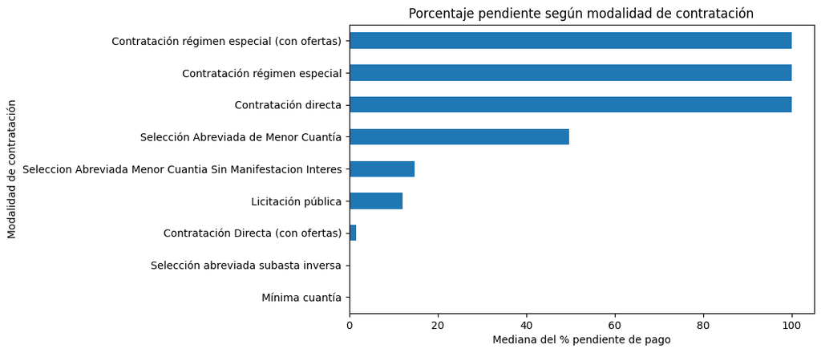

```python
mediana_pago = resumen_pago["median"].sort_values()

mediana_pago.plot(
    kind="barh",
    figsize=(8, 5)
)

plt.xlabel("Mediana del % pendiente de pago")
plt.ylabel("Modalidad de contratación")
plt.title("Porcentaje pendiente según modalidad de contratación")
plt.show()
```

La mediana del porcentaje pendiente de pago cambia bastante entre las modalidades de contratación, y la gráfica deja ver estas diferencias con claridad. Las barras más largas son las de Contratación directa, Contratación régimen especial y Contratación régimen especial (con ofertas), todas con una mediana de 100%, lo que significa que en estas modalidades al menos la mitad de los contratos finalizados todavía registra el valor completo como pendiente de pago.

En el otro extremo, la gráfica muestra barras prácticamente nulas para Mínima cuantía y Selección abreviada subasta inversa, con medianas de apenas 0,007% y 0,16% respectivamente, y Contratación Directa (con ofertas) también tiene una mediana baja de 1,66%. Entre estos dos extremos quedan Licitación pública, con 12,03%, Selección Abreviada Menor Cuantía Sin Manifestación de Interés, con 14,81%, y Selección Abreviada de Menor Cuantía, cuya mediana llega a 49,75%.

La gráfica muestra entonces una separación bastante marcada entre las modalidades: algunas tienen medianas cercanas o iguales al 100% pendiente, mientras que en otras el valor típico está prácticamente en 0%. Descriptivamente esto indica que el comportamiento del saldo pendiente de los contratos finalizados cambia según la modalidad de contratación, así que esta característica puede ser relevante para focalizar la supervisión. Aun así, la gráfica solo representa las medianas y no toda la distribución de los contratos dentro de cada modalidad, y un porcentaje pendiente alto tampoco se debe interpretar por sí solo como una irregularidad, ya que también puede estar relacionado con la actualización o el registro administrativo de los pagos.

Los resultados de Selección Abreviada Menor Cuantía Sin Manifestación de Interés hay que tomarlos con más cuidado, dado que el análisis incluye solo 139 contratos en esta modalidad, mientras que otras categorías tienen varios miles de observaciones.

*Valor del contrato vs. porcentaje pendiente de pago*

Para complementar el análisis del presupuesto pendiente, se estudia si existe una relación entre el valor inicial del contrato y el porcentaje pendiente de pago en los contratos finalizados. Como ambas variables son cuantitativas y presentan una fuerte asimetría, se utiliza la correlación de Spearman, que permite medir relaciones monótonas sin exigir una relación lineal.

**Hipótesis**

- **H0:** no existe una asociación entre el valor del contrato y el porcentaje pendiente de pago.
- **H1:** existe una asociación entre el valor del contrato y el porcentaje pendiente de pago.

```python
muestra_pago = finalizados_pago.sample(frac=0.1, random_state=42)

x99 = finalizados_pago["valor_del_contrato"].quantile(.99)

muestra_pago_plot = muestra_pago.loc[muestra_pago["valor_del_contrato"] <= x99]
```

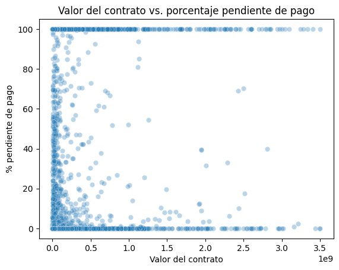

```python
sns.scatterplot(data=muestra_pago_plot,x="valor_del_contrato",y="pct_pendiente",alpha=.3)
plt.xlabel("Valor del contrato")
plt.ylabel("% pendiente de pago")
plt.title("Valor del contrato vs. porcentaje pendiente de pago")
plt.show()
```

```python
datos_pago_corr = finalizados_pago[["valor_del_contrato", "pct_pendiente"]].dropna()

rho, p_valor = spearmanr(datos_pago_corr["valor_del_contrato"],datos_pago_corr["pct_pendiente"])

print("Spearman:", rho)
print("p-valor:", p_valor)
```

```
Spearman: 0.05398382973524116
p-valor: 6.174485834743245e-66
```

El scatterplot no muestra una relación clara entre el valor del contrato y el porcentaje pendiente de pago. Para contratos de distintos valores se ven porcentajes pendientes muy diferentes, con una alta concentración de casos en 0% pendiente y otra en 100% pendiente, lo que indica que tanto contratos de menor como de mayor valor pueden aparecer completamente pagados o con todo su valor todavía registrado como pendiente, sin que se vea una tendencia visual fuerte entre las dos variables.

La correlación de Spearman fue de 0,054, lo que indica una asociación positiva pero muy débil entre las dos variables. El valor p obtenido fue menor a 0,001, así que se rechaza H0 y se concluye que sí hay evidencia estadística de una asociación entre el valor del contrato y el porcentaje pendiente de pago.

Aun así, la magnitud de la correlación es prácticamente nula, lo que indica que aunque la asociación resulta estadísticamente significativa, el valor del contrato por sí solo tiene muy poca capacidad para explicar el porcentaje pendiente de pago. Esta significancia probablemente está influenciada por el gran número de observaciones disponibles, así que para la focalización de la supervisión esta variable no parece ser un criterio fuerte cuando se analiza de manera aislada.

*Modalidad de contratación vs. contratos finalizados sin liquidar*

Se analiza si la proporción de contratos finalizados que todavía aparecen sin liquidar cambia según la modalidad de contratación. Para esto se utiliza una tabla cruzada con frecuencias relativas, calculando los porcentajes dentro de cada modalidad. De esta manera se pueden comparar las modalidades aunque tengan cantidades diferentes de contratos.

```python
tabla_liquidacion = pd.crosstab(finalizados["modalidad_de_contratacion"],finalizados["sin_liquidar"],normalize="index") * 100
tabla_liquidacion
```

| sin_liquidar modalidad_de_contratacion | False | True |
| --- | --- | --- |
| Contratación Directa (con ofertas) | 52.239341 | 47.760659 |
| Contratación directa | 34.799555 | 65.200445 |
| Contratación régimen especial | 27.861362 | 72.138638 |
| Contratación régimen especial (con ofertas) | 18.256692 | 81.743308 |
| Licitación pública | 56.088889 | 43.911111 |
| Mínima cuantía | 44.296287 | 55.703713 |
| Seleccion Abreviada Menor Cuantia Sin Manifestacion Interes | 71.942446 | 28.057554 |
| Selección Abreviada de Menor Cuantía | 53.846154 | 46.153846 |
| Selección abreviada subasta inversa | 55.631558 | 44.368442 |

```python
finalizados["modalidad_de_contratacion"].value_counts()
```

```
modalidad_de_contratacion
Mínima cuantía                                                 61346
Selección abreviada subasta inversa                            17251
Contratación régimen especial                                   8973
Selección Abreviada de Menor Cuantía                            4719
Contratación régimen especial (con ofertas)                     2914
Contratación Directa (con ofertas)                              2791
Contratación directa                                            1796
Licitación pública                                              1125
Seleccion Abreviada Menor Cuantia Sin Manifestacion Interes      139
Name: count, dtype: int64
```

La gráfica muestra el porcentaje de contratos finalizados que todavía aparecen sin liquidar dentro de cada modalidad de contratación. Se utilizan porcentajes en lugar de cantidades absolutas para hacer comparables las modalidades, ya que el número de contratos es diferente entre ellas.

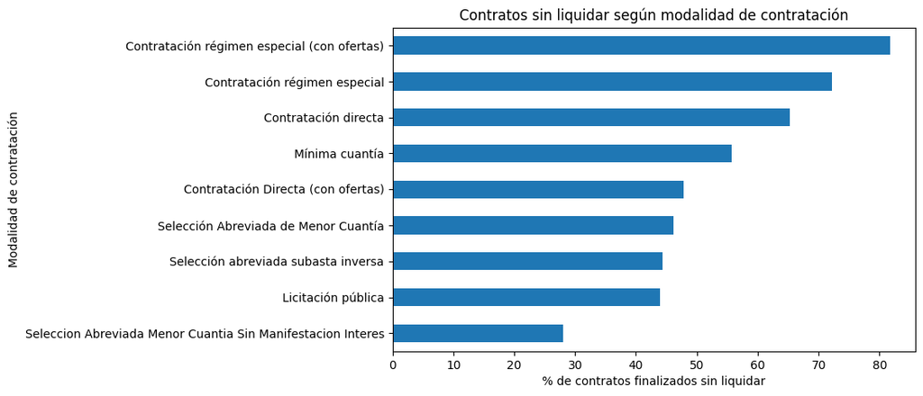

```python
porcentaje_sin_liquidar = tabla_liquidacion[True].sort_values()
porcentaje_sin_liquidar.plot(kind="barh", figsize=(8, 5))
plt.xlabel("% de contratos finalizados sin liquidar")
plt.ylabel("Modalidad de contratación")
plt.title("Contratos sin liquidar según modalidad de contratación")
plt.show()
```

La proporción de contratos finalizados que todavía aparecen sin liquidar cambia bastante según la modalidad de contratación. La mayor proporción se ve en Contratación régimen especial (con ofertas), donde el 81,74% de los contratos finalizados aparece sin liquidar, y le siguen Contratación régimen especial con 72,14% y Contratación directa con 65,20%. Es decir que en estas modalidades una parte considerable de los contratos que ya figuran como terminados o cerrados todavía no aparece con el proceso de liquidación completado en la base de datos.

En un nivel intermedio quedan Mínima cuantía con 55,70%, Contratación Directa (con ofertas) con 47,76%, Selección Abreviada de Menor Cuantía con 46,15%, Selección abreviada subasta inversa con 44,37% y Licitación pública con 43,91%. La menor proporción la tiene Selección Abreviada Menor Cuantía Sin Manifestación de Interés, con 28,06%, aunque este resultado hay que tomarlo con precaución porque esta modalidad solo tiene 139 contratos finalizados, mientras que las demás categorías cuentan con miles de observaciones.

La gráfica deja ver bien esta diferencia entre modalidades: las barras de régimen especial y contratación directa son bastante más largas que las de licitación pública o selección abreviada. Descriptivamente esto indica que la modalidad de contratación podría ser una característica útil para identificar grupos donde es más común encontrar contratos finalizados sin liquidar, y por eso podría considerarse como criterio de focalización para una supervisión más cercana.

Aun así, que un contrato aparezca finalizado y sin liquidar no implica automáticamente una irregularidad, dado que también puede estar relacionado con tiempos administrativos o con la actualización de la información registrada. Por esta razón este resultado se debe interpretar como una señal para priorizar revisión y no como evidencia directa de incumplimiento.

*Sector vs. presencia de adición de plazo*

A continuación se analiza si la frecuencia de contratos con adiciones de plazo cambia según el sector. Para esto se calculan porcentajes dentro de cada sector, de manera que la comparación no dependa únicamente de la cantidad de contratos que tenga cada grupo.

```python
analisis_df["sector"].value_counts()
```

```
sector
Servicio Público                                      37390
defensa                                               34585
No aplica/No pertenece                                24465
Salud y Protección Social                             22037
Ley de Justicia                                       20377
Trabajo                                               14759
Educación Nacional                                    10231
Ambiente y Desarrollo Sostenible                       8109
Transporte                                             4655
Cultura                                                2792
deportes                                               2610
Hacienda y Crédito Público                             2441
Industria                                              1807
Vivienda, Ciudad y Territorio                          1497
Planeación                                             1319
agricultura                                            1254
interior                                               1172
Minas y Energía                                        1025
Presidencia de la República                            1000
Inclusión Social y Reconciliación                       836
Tecnologías de la Información y las Comunicaciones      638
Ciencia Tecnología                                      481
Información Estadística                                 470
Relaciones Exteriores                                   332
Inteligencia Estratégica y Contrainteligencia           100
No Definido                                               9
Name: count, dtype: int64
```

```python
tabla_sector = pd.crosstab(analisis_df["sector"],analisis_df["adicion_plazo"],normalize="index") * 100
tabla_sector.sort_values(True, ascending=False)
```

| adicion_plazo sector | False | True |
| --- | --- | --- |
| Trabajo | 83.183142 | 16.816858 |
| Información Estadística | 83.617021 | 16.382979 |
| Minas y Energía | 84.878049 | 15.121951 |
| Inclusión Social y Reconciliación | 88.875598 | 11.124402 |
| interior | 88.993174 | 11.006826 |
| Cultura | 89.434097 | 10.565903 |
| Relaciones Exteriores | 89.759036 | 10.240964 |
| Salud y Protección Social | 89.889731 | 10.110269 |
| agricultura | 89.952153 | 10.047847 |
| Tecnologías de la Información y las Comunicaciones | 89.968652 | 10.031348 |
| Vivienda, Ciudad y Territorio | 90.046760 | 9.953240 |
| Educación Nacional | 90.225784 | 9.774216 |
| Ciencia Tecnología | 90.228690 | 9.771310 |
| Servicio Público | 90.238032 | 9.761968 |
| defensa | 90.281914 | 9.718086 |
| Ambiente y Desarrollo Sostenible | 91.774571 | 8.225429 |
| No aplica/No pertenece | 91.865931 | 8.134069 |
| Transporte | 92.158969 | 7.841031 |
| deportes | 92.260536 | 7.739464 |
| Industria | 93.082457 | 6.917543 |
| Planeación | 93.100834 | 6.899166 |
| Hacienda y Crédito Público | 94.018845 | 5.981155 |
| Ley de Justicia | 94.415272 | 5.584728 |
| Presidencia de la República | 94.600000 | 5.400000 |
| Inteligencia Estratégica y Contrainteligencia | 97.000000 | 3.000000 |
| No Definido | 100.000000 | 0.000000 |

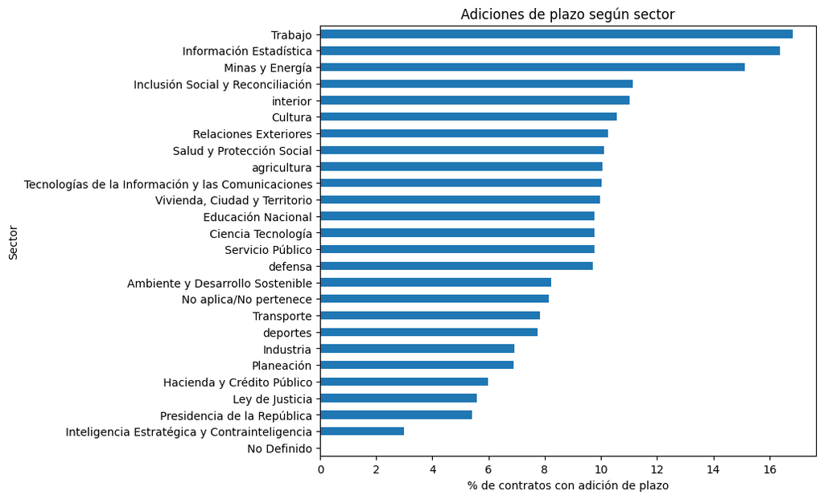

```python
porcentaje_sector = tabla_sector[True].sort_values()
porcentaje_sector.plot(kind="barh",figsize=(8, 7))

plt.xlabel("% de contratos con adición de plazo")
plt.ylabel("Sector")
plt.title("Adiciones de plazo según sector")
plt.show()
```

La frecuencia de contratos con adiciones de plazo cambia según el sector, dado que no todos presentan la misma proporción. La mayor se encuentra en Trabajo, donde el 16,82% de los 14.759 contratos presentó alguna adición de plazo, y le siguen Información Estadística con 16,38% y Minas y Energía con 15,12%; sin embargo, estos dos últimos tienen muchos menos contratos, con 470 y 1.025 observaciones respectivamente, así que sus porcentajes se deben tomar con más precaución porque están respaldados por muy pocos casos.

Otros sectores como Inclusión Social y Reconciliación, interior, Cultura, Salud y Protección Social, agricultura y Tecnologías de la Información y las Comunicaciones tienen proporciones cercanas o superiores al 10%, mientras que Hacienda y Crédito Público, Ley de Justicia y Presidencia de la República se quedan alrededor del 5% al 6%. La categoría No Definido da 0%, pero como solo tiene 9 contratos, no resulta representativa para hacer comparaciones.

La gráfica confirma que las adiciones de plazo no se presentan con la misma frecuencia en todos los sectores. En particular, Trabajo combina una proporción relativamente alta de adiciones con un número considerable de contratos, así que aparece como un sector relevante para tener en cuenta en la focalización de la supervisión, mientras que los porcentajes altos que se ven en sectores con pocos contratos hay que interpretarlos con más cautela, dado que un solo caso puede mover mucho el porcentaje cuando el grupo es tan pequeño. Estos resultados son descriptivos y no implican que pertenecer a un sector específico cause las adiciones de plazo.

*Destino del gasto vs. contratos finalizados sin liquidar*

A continuación se analiza si la proporción de contratos finalizados que todavía aparecen sin liquidar cambia según el destino del gasto. Para hacer comparables las categorías se calculan porcentajes dentro de cada destino, ya que la cantidad de contratos puede ser diferente entre los grupos.

```python
finalizados["destino_gasto"].value_counts()
```

```
destino_gasto
Funcionamiento    61471
Inversión         38995
No Definido         325
No aplica           263
Name: count, dtype: int64
```

```python
tabla_destino = pd.crosstab(finalizados["destino_gasto"],finalizados["sin_liquidar"],normalize="index") * 100
tabla_destino.sort_values(True, ascending=False)
```

| sin_liquidar destino_gasto | False | True |
| --- | --- | --- |
| No aplica | 2.281369 | 97.718631 |
| Inversión | 41.607898 | 58.392102 |
| Funcionamiento | 46.799304 | 53.200696 |
| No Definido | 48.923077 | 51.076923 |

La gráfica muestra el porcentaje de contratos finalizados que permanecen sin liquidar dentro de cada destino del gasto. El uso de frecuencias relativas permite comparar las categorías independientemente de la cantidad de contratos que tenga cada una.

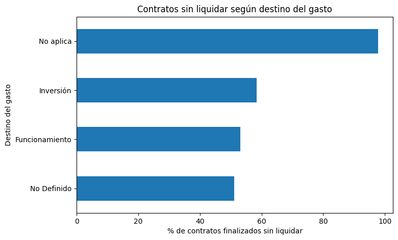

```python
porcentaje_destino = tabla_destino[True].sort_values()
porcentaje_destino.plot(kind="barh",figsize=(8, 5))

plt.xlabel("% de contratos finalizados sin liquidar")
plt.ylabel("Destino del gasto")
plt.title("Contratos sin liquidar según destino del gasto")
plt.show()
```

La proporción de contratos finalizados sin liquidar cambia según el destino del gasto. La categoría No aplica tiene el porcentaje más alto, con 97,72% de contratos sin liquidar, pero como solo contiene 263 contratos finalizados, este resultado hay que tomarlo con precaución y no parece adecuado usarlo por sí solo como criterio de focalización.

Entre las categorías con más observaciones, Inversión tiene una proporción de contratos sin liquidar de 58,39% sobre 38.995 contratos, mientras que Funcionamiento tiene 53,20% sobre 61.471 contratos, así que la gráfica deja ver que la diferencia entre estas dos categorías principales es relativamente moderada, de unos cinco puntos porcentuales. No Definido, por su parte, registra 51,08%, pero corresponde solo a 325 contratos y además es una categoría sin clasificación específica del destino del gasto.

En términos descriptivos, los contratos destinados a inversión presentan una frecuencia algo mayor de contratos finalizados sin liquidar que los destinados a funcionamiento, aunque la diferencia entre las dos categorías principales no es tan marcada como la que se había visto antes entre modalidades de contratación. Esto sugiere que destino_gasto podría aportar información complementaria para la focalización de la supervisión, pero probablemente no sea un criterio suficientemente fuerte si se usa de manera aislada. Además, que un contrato aparezca sin liquidar se interpreta únicamente como una señal para revisión y no como evidencia directa de una irregularidad.

**Análisis multivariado mediante matriz de correlación**

Para complementar los análisis anteriores, se construye una matriz de correlación entre las principales variables cuantitativas utilizadas en el estudio: valor_del_contrato, dias_adicionados y pct_pendiente. Debido a la fuerte asimetría observada en estas variables, se utiliza la correlación de Spearman. El mapa de calor permite visualizar de manera conjunta la dirección y la intensidad de las asociaciones entre ellas.

```python
variables_corr = finalizados_pago[["valor_del_contrato", "dias_adicionados", "pct_pendiente"]]

matriz_corr = variables_corr.corr(method="spearman")
matriz_corr
```

|  | valor_del_contrato | dias_adicionados | pct_pendiente |
| --- | --- | --- | --- |
| valor_del_contrato | 1.000000 | 0.057355 | 0.053984 |
| dias_adicionados | 0.057355 | 1.000000 | -0.003675 |
| pct_pendiente | 0.053984 | -0.003675 | 1.000000 |

No se utilizó la correlación de Pearson ya que los scatterplots no mostraron relaciones aproximadamente lineales y las variables cuantitativas presentaron una fuerte asimetría. Por esta razón, se utilizó la correlación de Spearman en los análisis cuantitativos.

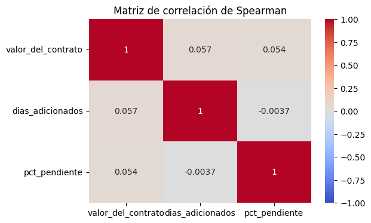

```python
plt.figure(figsize=(6, 4))
sns.heatmap(matriz_corr,annot=True,cmap="coolwarm",vmin=-1,vmax=1)
plt.title("Matriz de correlación de Spearman")
plt.show()
```

La matriz de correlación muestra que, dentro de los contratos finalizados con información válida de porcentaje pendiente, las asociaciones entre las variables cuantitativas analizadas son muy débiles.

La relación entre valor_del_contrato y dias_adicionados da una correlación de Spearman de 0,057, mientras que entre valor_del_contrato y pct_pendiente es de 0,054. En ambos casos la dirección es positiva, pero la magnitud está muy cerca de cero, así que no se ve una relación fuerte entre estas variables dentro de este subconjunto de contratos.

La relación más débil se da entre dias_adicionados y pct_pendiente, con una correlación de -0,0037, prácticamente igual a cero. El mapa de calor confirma visualmente que ninguna de las relaciones entre variables distintas tiene una intensidad importante, dado que los valores están muy próximos a cero. Los valores iguales a 1 en la diagonal corresponden a la correlación de cada variable consigo misma y no representan un hallazgo adicional.

En conjunto, esto sugiere que las desviaciones de plazo y de ejecución presupuestal no parecen estar fuertemente relacionadas entre sí, y que el valor del contrato tampoco presenta una asociación fuerte con estas desviaciones cuando se analizan juntas en los contratos finalizados. Esto refuerza la idea de que la focalización de la supervisión no debería basarse solo en una variable cuantitativa aislada, sino considerar también características categóricas como la modalidad de contratación y el sector.

La relación dias_adicionados vs. pct_pendiente es prácticamente nula con -0,0037. Vamos a realizar una prueba de hipotesis

**Hipótesis**

- **H0:** no existe una asociación entre los días adicionados y el porcentaje pendiente de pago.
- **H1:** existe una asociación entre los días adicionados y el porcentaje pendiente de pago.

```python
rho, p_valor = spearmanr(finalizados_pago["dias_adicionados"],finalizados_pago["pct_pendiente"])

print("Spearman:", rho)
print("p-valor:", p_valor)
```

```
Spearman: -0.0036745399563184364
p-valor: 0.24338033501602213
```

La correlación de Spearman entre dias_adicionados y pct_pendiente fue de -0,0037, un valor prácticamente igual a cero, lo que indica que no hay una relación monotónica entre las dos variables.

El valor p fue de 0,243, superior al nivel de significancia de 0,05, así que no se rechaza H0 y no se encuentra evidencia estadística suficiente para decir que existe una asociación entre los días adicionados y el porcentaje pendiente de pago en los contratos finalizados analizados.

Esto indica que una mayor cantidad de días adicionados no necesariamente viene acompañada de un mayor o menor porcentaje pendiente de pago. Por lo tanto, las desviaciones de plazo y de ejecución presupuestal parecen comportarse de manera independiente en este análisis, y pueden representar señales distintas para la focalización de la supervisión.

**Resumen de las pruebas de hipotesis**

A continuación se resumen las pruebas de hipótesis que se hicieron para las relaciones entre variables cuantitativas, usando un nivel de significancia de 0,05: cuando el valor p es menor a 0,05 se rechaza H0, y si no, no se rechaza.

```python
rho_1, p_1 = spearmanr(analisis_df["valor_del_contrato"],analisis_df["dias_adicionados"])

rho_2, p_2 = spearmanr(finalizados_pago["valor_del_contrato"],finalizados_pago["pct_pendiente"])

rho_3, p_3 = spearmanr(finalizados_pago["dias_adicionados"],finalizados_pago["pct_pendiente"])
```

```python
resumen_hipotesis = pd.DataFrame({
    "Relación": [
        "Valor del contrato vs. días adicionados",
        "Valor del contrato vs. % pendiente",
        "Días adicionados vs. % pendiente"
    ],
    "Spearman": [rho_1, rho_2, rho_3],
    "p-valor": [p_1, p_2, p_3],
    "Decisión": [
        "Se rechaza H0" if p_1 < 0.05 else "No se rechaza H0",
        "Se rechaza H0" if p_2 < 0.05 else "No se rechaza H0",
        "Se rechaza H0" if p_3 < 0.05 else "No se rechaza H0"
    ]
})

resumen_hipotesis
```

|  | Relación | Spearman | p-valor | Decisión |
| --- | --- | --- | --- | --- |
| 0 | Valor del contrato vs. días adicionados | 0.186366 | 0.000000e+00 | Se rechaza H0 |
| 1 | Valor del contrato vs. % pendiente | 0.053984 | 6.174486e-66 | Se rechaza H0 |
| 2 | Días adicionados vs. % pendiente | -0.003675 | 2.433803e-01 | No se rechaza H0 |

Las pruebas dan resultados distintos dependiendo de la relación que se analice. Por un lado, se encontró una asociación estadísticamente significativa entre el valor del contrato y los días adicionados, aunque con una magnitud débil (rho = 0,186), y también apareció una asociación significativa entre el valor del contrato y el porcentaje pendiente de pago, pero con una correlación muy cercana a cero (rho = 0,054), así que aunque estadísticamente existe, su importancia práctica termina siendo bastante limitada.

En cambio, la relación entre los días adicionados y el porcentaje pendiente de pago no resultó significativa (rho = -0,0037; p = 0,243), por lo que no hay evidencia suficiente para afirmar que estas dos desviaciones estén asociadas entre sí. Esto muestra que una relación puede ser estadísticamente significativa sin ser necesariamente fuerte, sobre todo cuando se cuenta con una cantidad tan grande de observaciones como en este caso.

**Insights principales del desarollo de la estrategia**

Los resultados muestran que las características categóricas de los contratos permiten diferenciar mejor algunos comportamientos de ejecución que el valor contractual por sí solo. La modalidad_de_contratacion fue una de las variables con los patrones más claros: en las adiciones de plazo, Licitación pública presentó la mayor proporción de contratos con adición, mientras que modalidades como Mínima cuantía, Contratación directa y Contratación régimen especial mostraron porcentajes menores.

La modalidad también mostró diferencias importantes en el porcentaje pendiente de pago. Contratación directa, Contratación régimen especial y Contratación régimen especial (con ofertas) tuvieron medianas de 100% pendiente entre los contratos finalizados, mientras que Mínima cuantía y Selección abreviada subasta inversa tuvieron medianas prácticamente iguales a cero. De manera similar, las mayores proporciones de contratos finalizados sin liquidar se encontraron en Contratación régimen especial (con ofertas), Contratación régimen especial y Contratación directa.

El sector también mostró diferencias en la frecuencia de adiciones de plazo. El sector Trabajo destacó porque combinó una proporción relativamente alta de contratos con adición con una cantidad considerable de observaciones, mientras que otros sectores presentaron porcentajes altos pero con un número menor de contratos, así que esos resultados hay que tomarlos con más precaución.

En cuanto al destino_gasto, los contratos de Inversión tuvieron una proporción de contratos finalizados sin liquidar ligeramente mayor que los de Funcionamiento, aunque la diferencia entre estas dos categorías fue menor que la que se había visto entre modalidades de contratación, así que esta variable parece aportar más información complementaria que constituir un criterio fuerte por sí sola.

Las variables cuantitativas, en cambio, mostraron asociaciones débiles. Aunque el valor del contrato presentó relaciones estadísticamente significativas tanto con los días adicionados como con el porcentaje pendiente de pago, las correlaciones fueron bajas, y tampoco se encontró una asociación significativa entre los días adicionados y el porcentaje pendiente, lo que indica que las desviaciones de plazo y de ejecución presupuestal representan señales distintas.

En conjunto, esto sugiere que para focalizar la supervisión resulta más útil combinar varias características del contrato que usar una sola de manera aislada. En particular, la modalidad de contratación y el sector aparecen como los criterios más relevantes, mientras que el valor contractual puede servir como una característica complementaria. Estas relaciones, eso sí, se interpretan únicamente como asociaciones y no como evidencia de causalidad o de irregularidad.

No se utilizó la correlación de Pearson porque los scatterplots no mostraron relaciones aproximadamente lineales y las variables cuantitativas presentaron una fuerte asimetría. Por esta razón, se utilizó la correlación de Spearman en los contrastes realizados.